# ¶ **Factors Contributing to the Trending Period of YouTube Videos** ¶

¶ 2023-04-15 ¶

# I. Data Preprocessing

## Load data

```r
setwd("C:/Users/Oooops/Documents/2023Spring/APAN5205/APAN5205 Project")
# read data
raw_data <- read.csv("US_youtube_trending_data.csv")
data <- raw_data # ready for data manipulation
library(jsonlite)  # load the jsonlite package
# Read the json file into a list
categories <- jsonlite::fromJSON("US_category_id.json")
```

## Data manipulation

```r
#
colnames(data)
```

```
##  [1] "video_id"          "title"             "publishedAt"
##  [4] "channelId"         "channelTitle"      "categoryId"
##  [7] "trending_date"     "tags"              "view_count"
## [10] "likes"             "dislikes"          "comment_count"
## [13] "thumbnail_link"    "comments_disabled" "ratings_disabled"
## [16] "description"
```

```r
dim(data) # 186190 17
```

```
## [1] 186190     16
```

```r
summary(data)
```

```
##    video_id            title           publishedAt         channelId
##  Length:186190      Length:186190      Length:186190      Length:186190
##  Class :character   Class :character   Class :character   Class :character
##  Mode  :character   Mode  :character   Mode  :character   Mode  :character
##
##
##
##  channelTitle         categoryId    trending_date          tags
##  Length:186190      Min.   : 1.00   Length:186190      Length:186190
##  Class :character   1st Qu.:17.00   Class :character   Class :character
##  Mode  :character   Median :20.00   Mode  :character   Mode  :character
##                     Mean   :18.83
##                     3rd Qu.:24.00
##                     Max.   :29.00
##    view_count            likes             dislikes      comment_count
##  Min.   :        0   Min.   :       0   Min.   :     0   Min.   :      0
##  1st Qu.:   479460   1st Qu.:   18807   1st Qu.:     0   1st Qu.:   1344
##  Median :   972788   Median :   43374   Median :   130   Median :   2973
##  Mean   :  2499437   Mean   :  130156   Mean   :  1638   Mean   :  10890
##  3rd Qu.:  2184866   3rd Qu.:  108083   3rd Qu.:   937   3rd Qu.:   7041
##  Max.   :277791741   Max.   :16021534   Max.   :879354   Max.   :6738537
##  thumbnail_link     comments_disabled  ratings_disabled   description
##  Length:186190      Length:186190      Length:186190      Length:186190
##  Class :character   Class :character   Class :character   Class :character
##  Mode  :character   Mode  :character   Mode  :character   Mode  :character
##
##
##
```

```r
# change the time to year-month-date format
data$publishedAt<- as.Date(substr(data$publishedAt,1,10))
data$trending_date<- as.Date(substr(data$trending_date,1,10))

# add a category_name column based on json file
id <- categories$items$id
cat_dict <- categories$items$snippet$title
names(cat_dict) <- id
data$category_name <- cat_dict[as.character(data$categoryId)]
colnames(data)
```

```
##  [1] "video_id"          "title"             "publishedAt"
##  [4] "channelId"         "channelTitle"      "categoryId"
##  [7] "trending_date"     "tags"              "view_count"
## [10] "likes"             "dislikes"          "comment_count"
## [13] "thumbnail_link"    "comments_disabled" "ratings_disabled"
## [16] "description"       "category_name"
```

```r
# exclude data with comment and ratings disabled
data_exclude_disabled <- data[data$comments_disabled=="False" & data$ratings_disabled=="False",]
dim(data_exclude_disabled) # 182728     17
```

```
## [1] 182728     17
```

```r
table(data_exclude_disabled$comments_disabled)
```

```
##
##  False
## 182728
```

```r
table(data_exclude_disabled$ratings_disabled)
```

```
##
##  False
## 182728
```

```r
# all False, cleaned up
```

```r
# filter the needed columns
data_filtered <- data_exclude_disabled[,c("video_id","title","publishedAt","trending_date","channelTitle","category_name",                                      "tags","view_count","likes","dislikes","comment_count","description")]
dim(data_filtered) # 182728     12
```

```
## [1] 182728     12
```

```r
# there are plenty of tags named [None]
dim(data_filtered[data_filtered$tags=="[None]",])
```

```
## [1] 29645    12
```

We identified several videos with tag as “[None]”, which means these videos do not have a tag. We keep the tags with [None], and rename [None] as “NoTag”, as we suppose NoTag videos probably have lower trending days.

## Get the cleaned data set for analysis

Ideas and Rules:

1. Change tags = “[None]” to “NoTag” to reduce the naming issues.
2. Add a column of the year video published.
3. Calculate the number of trending days.
4. Keep only one row for each video at the first trending day

```r
# clean up the table
library(dplyr)
library(lubridate)
data_clean <- data_filtered %>%
  group_by(video_id) %>%
  mutate(tags = ifelse(tags == "[None]", "NoTag", tags)) %>%
  mutate(published_year = year(publishedAt)) %>%
  mutate(num_trending_days = n_distinct(trending_date)) %>%
  filter(trending_date == min(trending_date)) %>%
  rename(min_trending_date = trending_date, likes_first_day = likes,
         dislikes_first_day = dislikes, comment_count_first_day = comment_count, view_count_first_day = view_count)

head(data_clean)
```

```
## # A tibble: 6 × 14
## # Groups:   video_id [6]
##   video_id  title publishedAt min_trending_date channelTitle category_name tags
##   <chr>     <chr> <date>      <date>            <chr>        <chr>         <chr>
## 1 3C66w5Z0… I AS… 2020-08-11  2020-08-12        Brawadis     People & Blo… braw…
## 2 M9Pmf9AB… Apex… 2020-08-11  2020-08-12        Apex Legends Gaming        Apex…
## 3 J78aPJ3V… I le… 2020-08-11  2020-08-12        jackseptice… Entertainment jack…
## 4 kXLn3Hkp… XXL … 2020-08-11  2020-08-12        XXL          Music         xxl …
## 5 VIUo6yap… Ulti… 2020-08-11  2020-08-12        Mr. Kate     Howto & Style The …
## 6 w-aidBdv… I Ha… 2020-08-11  2020-08-12        Professor L… Entertainment Prof…
## # ℹ 7 more variables: view_count_first_day <int>, likes_first_day <int>,
## #   dislikes_first_day <int>, comment_count_first_day <int>, description <chr>,
## #   published_year <dbl>, num_trending_days <int>
```

```r
colnames(data_clean)
```

```
##  [1] "video_id"                "title"
##  [3] "publishedAt"             "min_trending_date"
##  [5] "channelTitle"            "category_name"
##  [7] "tags"                    "view_count_first_day"
##  [9] "likes_first_day"         "dislikes_first_day"
## [11] "comment_count_first_day" "description"
## [13] "published_year"          "num_trending_days"
```

General idea: title: text mining, category_name: dummy variables, channelTitle, tags: dummy variables using frequency.

Note that the final variables used in building models should exclude: video_id, title, publishedAt, min_trending_date, channelTitle, tags, description, published_year

## Title

For title, we use TF and TF-IDF term frequency to analyze the frequency of words in title of videos. We create data frame for TF values and TF-IDF values for each video.

```r
# Create a corpus of the reviews from the "title" using library(tm).
# Examine the review in document “617”.
library(tm)
corpus = Corpus(VectorSource(data_clean$title))
corpus[[617]][1]
```

```
## $content
## [1] "The Neighbourhood - Devil's Advocate (Official Video)"
```

```r
# Preprocess the corpus of reviews created in the previous question using functions from library(tm).
# Specifically, Use tm_map to
# (a) transform text to lower case,
corpus = tm_map(corpus,FUN = content_transformer(tolower))
# (b) remove punctuation,
corpus = tm_map(corpus,FUN = removePunctuation)
# (c) remove English stopwords using the following dictionary tm::stopwords("english")
corpus = tm_map(corpus,FUN = removeWords,c(stopwords('english')))
# (d) remove numbers
corpus = tm_map(corpus,FUN = removeNumbers)
# (e) remove whitespace
corpus = tm_map(corpus,FUN = stripWhitespace)
# (f) stem words
corpus = tm_map(corpus,FUN = stemDocument)
corpus[[617]][1]
```

```
## $content
## [1] "neighbourhood devil advoc offici video"
```

```r
# Create a Document Term Matrix from the corpus of pre-processed text.
# Use the default, i.e., weight by Term Frequency.
dtm = DocumentTermMatrix(corpus)
dtm
```

```
## <<DocumentTermMatrix (documents: 34218, terms: 20358)>>
## Non-/sparse entries: 197431/696412613
## Sparsity           : 100%
## Maximal term length: 68
## Weighting          : term frequency (tf)
```

```r
# To make this matrix more dense, reduce the number of terms to a more reasonable number
# by only keeping terms that appear in at least 1% of documents.
# Save the result as ‘xdtm’.

xdtm = removeSparseTerms(dtm,sparse = 0.99)
xdtm
```

```
## <<DocumentTermMatrix (documents: 34218, terms: 46)>>
## Non-/sparse entries: 34522/1539506
## Sparsity           : 98%
## Maximal term length: 9
## Weighting          : term frequency (tf)
```

```r
dict = findFreqTerms(DocumentTermMatrix(Corpus(VectorSource(data_clean$title))),
                     lowfreq = 0)
dict_corpus = Corpus(VectorSource(dict))

# TF value matrix
xdtm = as.data.frame(as.matrix(xdtm))
colnames(xdtm) = stemCompletion(x = colnames(xdtm),
                                dictionary = dict_corpus,
                                type='prevalent')
colnames(xdtm) = make.names(colnames(xdtm))
colnames(xdtm) = paste0("tf_", colnames(xdtm))
sort(colSums(xdtm),decreasing = T)
```

```
##  tf_official     tf_video tf_highlight tf_minecraft   tf_trailer      tf_game
##         4113         3554         1738         1638         1526         1364
##     tf_music       tf_new     tf_short       tf_day     tf_first     tf_world
##         1333         1220         1011          903          771          697
##    tf_season      tf_full       tf_nba      tf_live       tf_get     tf_react
##          657          626          550          546          526          520
##      tf_feat     tf_final       tf_lil  tf_fortnite tf_challenge   tf_episode
##          500          495          476          470          457          453
##      tf_life       tf_win      tf_make      tf_best    tf_reveal      tf_week
##          449          448          441          431          430          429
##    tf_update     tf_house    tf_teaser      tf_part  tf_survival         tf_X
##          413          406          405          404          402          400
##     tf_sport       tf_one     tf_audio     tf_trial      tf_show       tf_can
##          397          396          394          390          386          384
##    tf_babies      tf_time   tf_oficial      tf_play
##          382          378          370          351
```

```r
# TF-IDF value matrix
dtm_tfidf = DocumentTermMatrix(x=corpus,
                               control = list(weighting=function(x) weightTfIdf(x,normalize=T)))
xdtm_tfidf = removeSparseTerms(dtm_tfidf,sparse = 0.99)
xdtm_tfidf = as.data.frame(as.matrix(xdtm_tfidf))
colnames(xdtm_tfidf) = stemCompletion(x = colnames(xdtm_tfidf),
                                      dictionary = dict_corpus,
                                      type='prevalent')

colnames(xdtm_tfidf) = make.names(colnames(xdtm_tfidf))
colnames(xdtm_tfidf) = paste0("tfidf_", colnames(xdtm_tfidf))
sort(colSums(xdtm_tfidf),decreasing = T)
```

```
##  tfidf_official     tfidf_video tfidf_minecraft   tfidf_trailer tfidf_highlight
##       2098.4254       1919.0911       1693.1716       1250.5436       1073.6224
##     tfidf_short      tfidf_game       tfidf_day       tfidf_new     tfidf_music
##       1063.6975       1041.6572        963.5522        962.5332        925.8573
##     tfidf_world     tfidf_first    tfidf_season  tfidf_fortnite  tfidf_survival
##        692.2494        656.2976        636.2546        586.5325        564.8750
##     tfidf_house       tfidf_get      tfidf_life tfidf_challenge      tfidf_full
##        563.4444        557.7119        549.7827        539.6637        523.9296
##     tfidf_final   tfidf_episode      tfidf_live      tfidf_make       tfidf_nba
##        522.2619        520.5363        520.0552        503.4800        503.0774
##    tfidf_reveal    tfidf_babies     tfidf_trial    tfidf_teaser      tfidf_best
##        491.7307        484.7057        484.5732        481.8580        471.3095
##      tfidf_time    tfidf_update       tfidf_can      tfidf_week      tfidf_part
##        470.2975        458.8022        458.3108        457.9101        449.4746
##     tfidf_react         tfidf_X      tfidf_play       tfidf_win     tfidf_audio
##        446.9304        433.8128        422.7897        422.4491        421.1566
##       tfidf_lil       tfidf_one      tfidf_show   tfidf_oficial      tfidf_feat
##        413.0090        398.7895        387.7429        378.5795        369.5175
##     tfidf_sport
##        303.4265
```

```r
colnames(xdtm_tfidf)
```

```
##  [1] "tfidf_official"  "tfidf_reveal"    "tfidf_first"     "tfidf_life"
##  [5] "tfidf_video"     "tfidf_challenge" "tfidf_trial"     "tfidf_trailer"
##  [9] "tfidf_lil"       "tfidf_get"       "tfidf_music"     "tfidf_react"
## [13] "tfidf_time"      "tfidf_teaser"    "tfidf_game"      "tfidf_house"
## [17] "tfidf_new"       "tfidf_babies"    "tfidf_world"     "tfidf_nba"
## [21] "tfidf_full"      "tfidf_highlight" "tfidf_feat"      "tfidf_make"
## [25] "tfidf_best"      "tfidf_day"       "tfidf_can"       "tfidf_live"
## [29] "tfidf_X"         "tfidf_final"     "tfidf_oficial"   "tfidf_episode"
## [33] "tfidf_win"       "tfidf_minecraft" "tfidf_survival"  "tfidf_show"
## [37] "tfidf_audio"     "tfidf_update"    "tfidf_short"     "tfidf_sport"
## [41] "tfidf_season"    "tfidf_part"      "tfidf_one"       "tfidf_play"
## [45] "tfidf_fortnite"  "tfidf_week"
```

Note: warning messages when use TF-IDF means some of the document have generated empty document during the process, so we might prefer using TF frequency. We will confirm and explain this later in model building section.

## Category_Name

For Category_Name, which is the category of the video, we do a variable transformation to tranform this variable to dummy variables. To avoid multicollinearity problem, we delete one of the dummy variable created: Travel & Events. When the dummy variables of all other variables is 0, the video is categorized as ‘Travel & Events’.

```r
library(fastDummies)
# Create dummy variables for category_name
dummy_category = dummy_cols(data_clean$category_name)
# remove variables that would result in multicolinearity problems
dummy_category$`.data` = NULL
dummy_category$`.data_Travel & Events` = NULL

# Use sub() to replace ".data" with "category" in each column name
colnames(dummy_category) = sub("\\.data", "category", colnames(dummy_category))
colnames(dummy_category) = make.names(colnames(dummy_category))
colnames(dummy_category)
```

```
##  [1] "category_Autos...Vehicles"      "category_Comedy"
##  [3] "category_Education"             "category_Entertainment"
##  [5] "category_Film...Animation"      "category_Gaming"
##  [7] "category_Howto...Style"         "category_Music"
##  [9] "category_News...Politics"       "category_Nonprofits...Activism"
## [11] "category_People...Blogs"        "category_Pets...Animals"
## [13] "category_Science...Technology"  "category_Sports"
```

```r
dim(dummy_category)
```

```
## [1] 34218    14
```

## Channel Title

For channel Title,

```r
channelTitle_df = data.frame(table(data_clean$channelTitle)) %>% arrange(desc(Freq))
head(channelTitle_df)
```

```
##           Var1 Freq
## 1          NFL  325
## 2          NBA  309
## 3   NBC Sports  130
## 4 SSSniperWolf  125
## 5      SSundee  109
## 6         ESPN   98
```

```r
dim(channelTitle_df) # 7069    2
```

```
## [1] 7069    2
```

The channelTitle has 7069 total values, we decide not to use channelTitle directly as one variable, because it takes too much time to operate these large amount of values. Therefore, we decided move on to use only part of the channelTitle as dummy variables We select channelTitles with frequency > 50 (total 47 channelTitles) and create dummy variables However, we noticed that there could also be multicollinearity problems because channels would probably be high correlated to tags, category, and title.

```r
selected_channel <- channelTitle_df[channelTitle_df$Freq > 50, "Var1"]
library(stringr)
# exclude redundant variables
data_channels <- subset(data_clean, select=c(channelTitle))

# create dummy variables for each selected tag
data_channels_50 <- data_channels

for (cnl in selected_channel) {
  # Escape any special characters in the tag string
  escaped_cnl <- str_escape(cnl)

  # Use the escaped tag string in the regular expression pattern
  cnl_col <- str_detect(data_channels_50$channelTitle, fixed(escaped_cnl))
  cnl_col <- as.integer(cnl_col)

  # Create a new column in data_tags for the tag
  col_name <- paste0("channel_", cnl)
  data_channels_50[[col_name]] <- cnl_col
}
data_channels_50$channelTitle <- NULL

colnames(data_channels_50) <- make.names(colnames(data_channels_50))
colnames(data_channels_50)
```

```
##  [1] "channel_NFL"
##  [2] "channel_NBA"
##  [3] "channel_NBC.Sports"
##  [4] "channel_SSSniperWolf"
##  [5] "channel_SSundee"
##  [6] "channel_ESPN"
##  [7] "channel_Saturday.Night.Live"
##  [8] "channel_SpaceX"
##  [9] "channel_ESPN.FC"
## [10] "channel_MrBeast.Gaming"
## [11] "channel_Fortnite"
## [12] "channel_Genshin.Impact"
## [13] "channel_Skip.and.Shannon..UNDISPUTED"
## [14] "channel_UFC...Ultimate.Fighting.Championship"
## [15] "channel_NBA.on.TNT"
```

[output cut: 32 more lines]

These are the channels we decided to use in our analysis and build models.

## Tags

For tags, we have two format of data. One is labeled as “NoTag”, and the other is labeled as a string of a number of tags a video have. For example: “brawadis|prank|basketball|skits|ghost|funny videos|vlog|vlogging|NBA|browadis|challenges|bmw i8|faze rug|faze rug brother|mama rug and papa rug”.

Our idea is to use both type of data in creating dummy variables which identifies a video has no tag, or is labeled as one of the tags in the tag string. For the data with tags, we splitted the tag string into blocks of words, and the dummy variable will show if that word exist in the tags string.

```r
# create dummy variables of tags
# split the tags according to "|"
tag_list <- strsplit(data_clean$tags, "\\|")
# Convert the resulting list to a vector
tag_vec <- unlist(tag_list)
# Calculate the frequency of each label
tag_freq <- table(tag_vec)
tag_df <- data.frame(tag_freq) %>% arrange(desc(Freq))
# Get top 20 titles in Frequency
head(tag_df,20)
```

```
##            tag_vec Freq
## 1            NoTag 5702
## 2            funny 2052
## 3           comedy 1287
## 4        minecraft 1269
## 5        challenge  869
## 6             vlog  677
## 7           gaming  662
## 8             news  589
## 9       highlights  546
## 10             NBA  539
## 11          tiktok  502
## 12       animation  495
## 13        fortnite  487
## 14 family friendly  471
## 15        football  467
## 16           video  467
## 17          how to  466
## 18           music  460
## 19             new  456
## 20             rap  456
```

To improve our model predict accuracy, we decided not to use all of the tags as dummy variables. We selected part of them which could be better fitted and explained in our model.

Our idea is to use two groups of different numbers of tag dummy variables, and compare which group could have better prediction power. We select tags with frequency > 200, and tags with frequency > 120 as our dummy variables of interest in our model, as we suggest tags with larger frequency in our data could have higher prediction power.

We also noticed that when a video’s tag is “NoTag”, all other tag dummy variables should be 0, which could possibly result multicollinearity problems. However, our selection of only group of tag dummy variables reduced the problem. In our created dummy variables data frame, all other variables labeled as 0 does not necessarily means the Tag is “NoTag”, so we reduced the multicollinearity problem for tag dummy variable. Besides, as we are interested in investigating how a “NoTag” video could affect the number of trending days, we still keep the dummy variable “NoTag” in our analysis.

```r
# select tags with frequency > 200
selected_tags <- tag_df[tag_df$Freq > 200, "tag_vec"]
library(stringr)
# exclude redundant variables
data_tags <- subset(data_clean, select=-c(video_id, title, publishedAt, min_trending_date, channelTitle, description, published_year))

# create dummy variables for each selected tag
data_tags_200 <- data_tags

for (tag in selected_tags) {
  # Escape any special characters in the tag string
  escaped_tag <- str_escape(tag)

  # Use the escaped tag string in the regular expression pattern
  tag_col <- str_detect(data_tags_200$tags, fixed(escaped_tag))
  tag_col <- as.integer(tag_col)

  # Create a new column in data_tags for the tag
  col_name <- paste0("tag_", tag)
  data_tags_200[[col_name]] <- tag_col
}
#colnames(data_tags_200)
colnames(data_tags_200) <- make.names(colnames(data_tags_200))
colnames(data_tags_200)
```

```
##  [1] "category_name"              "tags"
##  [3] "view_count_first_day"       "likes_first_day"
##  [5] "dislikes_first_day"         "comment_count_first_day"
##  [7] "num_trending_days"          "tag_NoTag"
##  [9] "tag_funny"                  "tag_comedy"
## [11] "tag_minecraft"              "tag_challenge"
## [13] "tag_vlog"                   "tag_gaming"
## [15] "tag_news"                   "tag_highlights"
## [17] "tag_NBA"                    "tag_tiktok"
## [19] "tag_animation"              "tag_fortnite"
## [21] "tag_family.friendly"        "tag_football"
## [23] "tag_video"                  "tag_how.to"
## [25] "tag_music"                  "tag_new"
## [27] "tag_rap"                    "tag_sports"
## [29] "tag_reaction"               "tag_game"
```

[output cut: 31 more lines]

```r
#
# select tags with frequency > 120
selected_tags_120 <- tag_df[tag_df$Freq > 120, "tag_vec"]
# create dummy variables for each selected tag
data_tags_120 <- data_tags

for (tag in selected_tags_120) {
  # Escape any special characters in the tag string
  escaped_tag <- str_escape(tag)

  # Use the escaped tag string in the regular expression pattern
  tag_col <- str_detect(data_tags_120$tags, fixed(escaped_tag))
  tag_col <- as.integer(tag_col)

  # Create a new column in data_tags for the tag
  col_name <- paste0("tag_", tag)
  data_tags_120[[col_name]] <- tag_col
}
dim(data_tags_120) # 34218   208
```

```
## [1] 34218   194
```

```r
#colnames(data_tags_120)
colnames(data_tags_120) <- make.names(colnames(data_tags_120))
colnames(data_tags_120)
```

```
##   [1] "category_name"              "tags"
##   [3] "view_count_first_day"       "likes_first_day"
##   [5] "dislikes_first_day"         "comment_count_first_day"
##   [7] "num_trending_days"          "tag_NoTag"
##   [9] "tag_funny"                  "tag_comedy"
##  [11] "tag_minecraft"              "tag_challenge"
##  [13] "tag_vlog"                   "tag_gaming"
##  [15] "tag_news"                   "tag_highlights"
##  [17] "tag_NBA"                    "tag_tiktok"
##  [19] "tag_animation"              "tag_fortnite"
##  [21] "tag_family.friendly"        "tag_football"
##  [23] "tag_video"                  "tag_how.to"
##  [25] "tag_music"                  "tag_new"
##  [27] "tag_rap"                    "tag_sports"
##  [29] "tag_reaction"               "tag_game"
```

[output cut: 82 more lines]

## Combine channel, tags and title

Combine all variables proceeded into a large data frame.

1. data_1 : with tags frequency > 200, and using tf frequency
2. data_2 : with tags frequency > 200, and using tf-idf frequency
3. data_3 : with tags frequency > 120, and using tf frequency
4. data_4 : with tags frequency > 120, and using tf-idf frequency

Note: tf-idf might be not powerful as we got warning message of missing values.

create these 4 datasets and we will use them to compare which could have the best predict results.

```r
dim(data_tags_200) # 34218   92
```

```
## [1] 34218    92
```

```r
dim(data_tags_120) # 34218   194
```

```
## [1] 34218   194
```

```r
dim(xdtm) # 34218    46
```

```
## [1] 34218    46
```

```r
dim(xdtm_tfidf) # 34218    46
```

```
## [1] 34218    46
```

```r
dim(data_channels_50) # 34218    47
```

```
## [1] 34218    47
```

```r
dim(dummy_category) # 34218 14
```

```
## [1] 34218    14
```

```r
data_channels_category = cbind(data_channels_50,dummy_category)

#colnames(data_channels_category)
#colnames(data_tags_200)

data_1 = cbind(subset(data_tags_200,select = -c(category_name,tags)),data_channels_category)
data_1 = cbind(data_1, xdtm)
dim(data_1) # 34218   197
```

```
## [1] 34218   197
```

```r
data_2 = cbind(subset(data_tags_200,select=-c(category_name,tags)),data_channels_category)
data_2 = cbind(data_2, xdtm_tfidf)
dim(data_2) # 34218   197
```

```
## [1] 34218   197
```

```r
data_3 = cbind(subset(data_tags_120,select = -c(category_name,tags)),data_channels_category)
data_3 = cbind(data_3, xdtm)
dim(data_3) # 34218     299
```

```
## [1] 34218   299
```

```r
data_4 = cbind(subset(data_tags_120,select = -c(category_name,tags)),data_channels_category)
data_4 = cbind(data_4, xdtm_tfidf)
dim(data_4) # 34218     299
```

```
## [1] 34218   299
```

```r
colnames(data_1)
```

```
##   [1] "view_count_first_day"
##   [2] "likes_first_day"
##   [3] "dislikes_first_day"
##   [4] "comment_count_first_day"
##   [5] "num_trending_days"
##   [6] "tag_NoTag"
##   [7] "tag_funny"
##   [8] "tag_comedy"
##   [9] "tag_minecraft"
##  [10] "tag_challenge"
##  [11] "tag_vlog"
##  [12] "tag_gaming"
##  [13] "tag_news"
##  [14] "tag_highlights"
##  [15] "tag_NBA"
```

[output cut: 182 more lines]

```r
#colnames(data_3)
```

# II.Model Building

## Simple linear regression

We use the data with all needed variables and fit a linear regression model.

```r
# with freq > 200
# split test and train
set.seed(617)
split_1 = sample(1:nrow(data_1), nrow(data_1)*0.80)
train_1 = data_1[split_1,]
test_1 = data_1[-split_1,]
dim(train_1)
```

```
## [1] 27374   197
```

```r
set.seed(617)
split_2 = sample(1:nrow(data_2), nrow(data_2)*0.80)
train_2 = data_2[split_2,]
test_2 = data_2[-split_2,]
dim(train_2)
```

```
## [1] 27374   197
```

```r
set.seed(617)
split_3 = sample(1:nrow(data_3), nrow(data_3)*0.80)
train_3 = data_3[split_3,]
test_3 = data_3[-split_3,]
dim(train_3)
```

```
## [1] 27374   299
```

```r
set.seed(617)
split_4 = sample(1:nrow(data_4), nrow(data_4)*0.80)
train_4 = data_4[split_4,]
test_4 = data_4[-split_4,]
dim(train_4)
```

```
## [1] 27374   299
```

```r
# simple linear regression with all predictors
simple_model = num_trending_days~.
# data_1
train = train_1
test = test_1
set.seed(617)
lm_model = lm(simple_model,data=train)
#summary(lm_model)
pred = predict(lm_model, newdata = test)
rmse = sqrt(mean((pred-test$num_trending_days)^2)); rmse
```

```
## [1] 1.738289
```

```r
# 1.738289
# data_2
train = train_2
test = test_2
set.seed(617)
lm_model = lm(simple_model,data=train)
#summary(lm_model)
pred = predict(lm_model, newdata = test)
rmse = sqrt(mean((pred-test$num_trending_days)^2)); rmse
```

```
## [1] 1.740603
```

```r
# 1.740603
# data_3
train = train_3
test = test_3
set.seed(617)
lm_model = lm(simple_model,data=train)
#summary(lm_model)
pred = predict(lm_model, newdata = test)
rmse = sqrt(mean((pred-test$num_trending_days)^2)); rmse
```

```
## [1] 1.735979
```

```r
# 1.735979
# data_4
train = train_4
test = test_4
set.seed(617)
lm_model = lm(simple_model,data=train)
#summary(lm_model)
pred = predict(lm_model, newdata = test)
rmse = sqrt(mean((pred-test$num_trending_days)^2)); rmse
```

```
## [1] 1.737945
```

```r
# 1.737945
```

data_3 is best, let’s improve our model on data 3: with all tags > 120, and tf frequency on title text.

We mentioned TF-TDF will lose some data, and probably not good for our model.

With these reasons, we will focus on using data_3 to fit the best model.

## Feature selection

```r
# identify high correlation
dim(data_3)
```

```
## [1] 34218   299
```

```r
correlations <- cor(data_3)
high_correlations <- which(abs(correlations) >= 0.7 & upper.tri(correlations, diag = FALSE), arr.ind = TRUE)
correlation_df <- data.frame(col1 = rownames(correlations)[high_correlations[,1]],
                     col2 = colnames(correlations)[high_correlations[,2]],
                     correlation = correlations[high_correlations])
correlation_df %>% arrange(desc(correlation))
```

```
##                     col1                        col2 correlation
## 1        tag_sniper.wolf        channel_SSSniperWolf   1.0000000
## 2         tag_highlights               tag_highlight   0.9739070
## 3       tag_sssniperwolf             tag_sniper.wolf   0.9730238
## 4       tag_sssniperwolf        channel_SSSniperWolf   0.9730238
## 5            tag_offense               tag_top.plays   0.9630547
## 6  tag_American.Football                 tag_offense   0.9543722
## 7                tag_Hip                     tag_Hop   0.9512497
## 8          tag_touchdown                 tag_offense   0.9442639
## 9          tag_touchdown               tag_top.plays   0.9410949
## 10 tag_American.Football               tag_top.plays   0.9380781
## 11 tag_American.Football               tag_touchdown   0.9197656
## 12             tag_funny                     tag_fun   0.9175025
## 13       tag_no.swearing              tag_no.cursing   0.9051578
## 14           tag_defense                 tag_offense   0.8971375
```

[output cut: 41 more lines]

```r
#correlation_df %>% arrange(desc(col1))
```

Visualize:

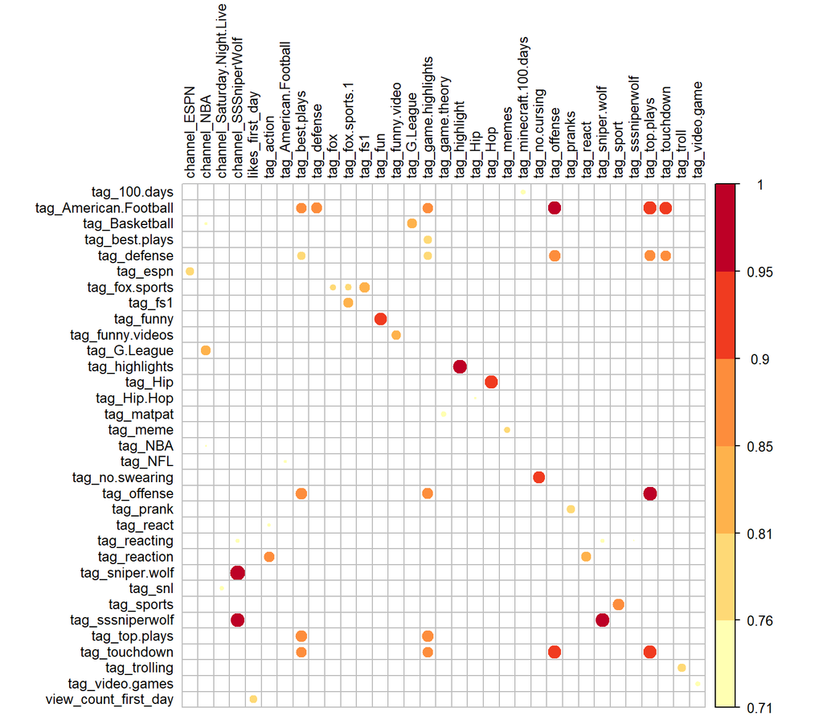

```r
#turn corr back into matrix in order to plot with corrplot
mtx_corr <- reshape2::acast(correlation_df, col1~col2, value.var="correlation")
library(corrplot)
library(RColorBrewer)
#plot correlations visually
corrplot(mtx_corr, is.corr=FALSE, tl.col="black", na.label=" ", tl.cex=0.8,
         cl.cex=0.8, col=brewer.pal(n=6, name="YlOrRd"))
```

### Solving multicollinearity problems

#### Method 1: remove highly correlated variables

To solve multicollinearity problems, our first idea is to remove highly correlated variables.

```r
# remove variables with correlation > 0.7
# view_count_first_day - tag_video.games - tag_trolling - tag_touchdown - tag_top.plays - tag_sssniperwolf - tag_sports -
# tag_sniper.wolf - tag_reaction - tag_react - tag_prank - tag_offense - tag_no.swearing - tag_NFL - tag_NBA - tag_meme -
# tag_matpat - tag_Hip.Hop - tag_Hip - tag_highlights - tag_G.League - tag_funny.videos - tag_funny - tag_fox.sports - tag_espn -
# tag_defense - tag_best.plays - tag_Basketball - tag_American.Football - tag_100.days
model_removed_1 = num_trending_days~.-view_count_first_day - tag_video.games - tag_trolling - tag_touchdown - tag_top.plays - tag_sssniperwolf - tag_sports -
  tag_sniper.wolf - tag_reaction - tag_react - tag_prank - tag_offense - tag_no.swearing - tag_NFL - tag_NBA - tag_meme -
  tag_matpat - tag_Hip.Hop - tag_Hip - tag_highlights - tag_G.League - tag_funny.videos - tag_funny - tag_fox.sports - tag_espn -
  tag_defense - tag_best.plays - tag_Basketball - tag_American.Football - tag_100.days

lm_model2 = lm(model_removed_1,
               data=train_3)

#summary(lm_model2)

pred2 = predict(lm_model2, newdata = test_3)
rmse2 = sqrt(mean((pred2-test_3$num_trending_days)^2)); rmse2
```

```
## [1] 1.746382
```

```r
# 1.746382 increased compared to original model
```

build model with less variables:

```r
# extract all significant variables in this model
summary_lm_model2 <- summary(lm_model2)
significant_vars <- summary_lm_model2$coefficients[summary_lm_model2$coefficients[, "Pr(>|t|)"] < 0.05, ]
significant_vars
```

```
##                                                   Estimate   Std. Error
## (Intercept)                                   5.490734e+00 1.415834e-01
## likes_first_day                               1.460678e-06 7.758020e-08
## comment_count_first_day                      -1.087398e-06 3.598519e-07
## tag_animation                                 3.065164e-01 8.872855e-02
## tag_music                                    -1.182739e-01 6.016757e-02
## tag_rap                                       1.352905e-01 5.520071e-02
## tag_Minecraft                                 2.270052e-01 8.412866e-02
## tag_Rap                                       2.341086e-01 1.004373e-01
## tag_trailer                                  -2.169863e-01 6.608147e-02
## tag_tik.tok                                   3.612873e-01 1.004736e-01
## tag_humor                                     3.256502e-01 1.497750e-01
## tag_minecraft.hardcore                        3.647273e-01 1.553035e-01
## tag_shorts                                   -2.697230e-01 1.046187e-01
## tag_Funny                                    -2.372022e-01 1.169310e-01
## tag_boxing                                    3.305785e-01 9.709533e-02
## tag_science                                   4.171384e-01 1.465134e-01
## tag_yt.cc.on                                 -3.678039e-01 1.702448e-01
## tag_pokemon                                   3.080993e-01 1.343160e-01
## tag_Comedy                                    2.930926e-01 1.365117e-01
## tag_BTS                                      -1.065159e+00 1.541431e-01
## tag_fox                                      -3.073339e-01 1.468421e-01
## tag_Sports                                    3.791184e-01 1.132319e-01
## tag_commentary                                2.841631e-01 1.444524e-01
## tag_among.us                                  4.507078e-01 1.378642e-01
## tag_tech                                     -3.769318e-01 1.272184e-01
## tag_mystery                                   4.901940e-01 1.396485e-01
## tag_Entertainment                            -2.320765e-01 1.017020e-01
## channel_NFL                                  -3.358973e-01 1.559844e-01
## channel_NBA                                  -7.940467e-01 1.568254e-01
## channel_NBC.Sports                           -9.915117e-01 2.339783e-01
## channel_SSSniperWolf                         -8.442527e-01 2.589246e-01
## channel_SSundee                              -7.827740e-01 1.801308e-01
## channel_Saturday.Night.Live                   1.093354e+00 4.231540e-01
## channel_SpaceX                               -6.445518e-01 2.171948e-01
## channel_Fortnite                              8.749737e-01 2.325917e-01
## channel_UFC...Ultimate.Fighting.Championship -1.138655e+00 2.487446e-01
## channel_The.Game.Theorists                    1.341428e+00 3.598728e-01
## channel_First.We.Feast                        6.329091e-01 2.786252e-01
## channel_Marvel.Entertainment                  1.156735e+00 2.718256e-01
```

[output cut: 83 more lines]

```
## category_People...Blogs                      -2.239515  2.513051e-02
## category_Sports                              -3.730575  1.914325e-04
## tf_official                                   2.253538  2.423321e-02
## tf_video                                      2.741427  6.121299e-03
## tf_challenge                                  2.284412  2.235503e-02
## tf_teaser                                    -2.673455  7.511932e-03
## tf_game                                      -2.655818  7.916250e-03
## tf_world                                      2.686821  7.217954e-03
## tf_day                                       -3.282604  1.029833e-03
## tf_show                                       2.578713  9.922147e-03
## tf_audio                                     -3.911481  9.195537e-05
## tf_update                                    -2.409457  1.598289e-02
## tf_short                                     -8.916963  5.087093e-19
## tf_sport                                      2.434585  1.491527e-02
## tf_week                                      -3.376962  7.339428e-04
```

```r
#rownames(significant_vars)
# build model with all these significant variables
model_removed_2 = num_trending_days ~ likes_first_day + comment_count_first_day + tag_animation + tag_music +
  tag_rap + tag_Minecraft + tag_Rap + tag_trailer + tag_tik.tok + tag_humor +
  tag_minecraft.hardcore + tag_shorts + tag_Funny + tag_boxing + tag_science +
  tag_yt.cc.on + tag_pokemon + tag_Comedy + tag_BTS + tag_fox + tag_Sports +
  tag_commentary + tag_among.us + tag_tech + tag_mystery + tag_Entertainment +
  channel_NFL + channel_NBA + channel_NBC.Sports + channel_SSSniperWolf +
  channel_SSundee + channel_Saturday.Night.Live + channel_SpaceX + channel_Fortnite +
  channel_UFC...Ultimate.Fighting.Championship + channel_The.Game.Theorists +
  channel_First.We.Feast + channel_Marvel.Entertainment + channel_Dude.Perfect +
  channel_Apex.Legends + channel_CBS.Sports.Golazo + channel_SMTOWN +
  channel_The.Film.Theorists + channel_BANGTANTV + channel_FOX.Soccer +
  channel_MrBeast + channel_BWF.TV + channel_DAZN.Boxing + channel_RDCworld1 +
  channel_BLACKPINK + category_Gaming + category_Music + category_People...Blogs +
  category_Sports + tf_official + tf_video + tf_challenge + tf_teaser + tf_game +
  tf_world + tf_day + tf_show + tf_audio + tf_update + tf_short + tf_sport + tf_week
lm_model3 = lm(model_removed_2,
               data=train_3)

#summary(lm_model3)

pred3 = predict(lm_model3, newdata = test_3)
rmse3 = sqrt(mean((pred3-test_3$num_trending_days)^2)); rmse3
```

```
## [1] 1.748824
```

```r
# 1.748824
```

#### Method 2: Use feature selection methods

```r
# Best subset selection
#library(leaps)
# takes too much time
#subsets = regsubsets(num_trending_days~.,data=train_tf_tags_200, nvmax=30, really.big = T)
#summary(subsets)
# stepwise variable selection
# start_mod = lm(model_removed_2,data=train_3)
# empty_mod = lm(model_removed_2,data=train_3)
# full_mod = lm(model_removed_1,data=train_3)
# this step take lots of time, I'll mute this and just keep the output model
# hybridStepwise = step(start_mod,
#                       scope=list(upper=full_mod,lower=empty_mod),
#                       direction='both')
# summary(hybridStepwise)
# model from stepwise variable selection:
model_removed_3 = num_trending_days ~ likes_first_day + comment_count_first_day +
  tag_animation + tag_music + tag_rap + tag_Minecraft + tag_Rap +
  tag_trailer + tag_tik.tok + tag_humor + tag_minecraft.hardcore +
  tag_shorts + tag_Funny + tag_boxing + tag_science + tag_yt.cc.on +
  tag_pokemon + tag_Comedy + tag_BTS + tag_fox + tag_Sports +
  tag_commentary + tag_among.us + tag_tech + tag_mystery +
  tag_Entertainment + channel_NFL + channel_NBA + channel_NBC.Sports +
  channel_SSSniperWolf + channel_SSundee + channel_Saturday.Night.Live +
  channel_SpaceX + channel_Fortnite + channel_UFC...Ultimate.Fighting.Championship +
  channel_The.Game.Theorists + channel_First.We.Feast + channel_Marvel.Entertainment +
  channel_Dude.Perfect + channel_Apex.Legends + channel_CBS.Sports.Golazo +
  channel_SMTOWN + channel_The.Film.Theorists + channel_BANGTANTV +
  channel_FOX.Soccer + channel_MrBeast + channel_BWF.TV + channel_DAZN.Boxing +
  channel_RDCworld1 + channel_BLACKPINK + category_Gaming +
  category_Music + category_People...Blogs + category_Sports +
  tf_official + tf_video + tf_challenge + tf_teaser + tf_game +
  tf_world + tf_day + tf_show + tf_audio + tf_update + tf_short +
  tf_sport + tf_week + tag_celebrities + tag_lil.durk + tag_minecraft.manhunt +
  channel_NBA.on.TNT + channel_Nintendo + tag_music.video +
  tag_education + tag_update + tf_minecraft + tag_NoTag + category_Nonprofits...Activism +
  tag_Hop + tag_minecraft.mod + tag_season + tag_news + tag_basketball +
  category_Science...Technology + category_Entertainment +
  category_Autos...Vehicles + tag_new.york + tf_live + tag_Disney +
  tag_diy + tag_fight + tag_UFC + channel_beIN.SPORTS.USA +
  tag_Soccer + channel_JYP.Entertainment + channel_MrBeast.Gaming +
  tag_atlantic.records + tag_no.cursing + tf_full + tf_lil +
  tf_make + channel_Clash.of.Clans + tag_fs1 + tag_sketch +
  tag_tommyinnit + channel_YoungBoy.Never.Broke.Again + tag_technology +
  tag_viral + tag_video + tf_get + tag_song + tag_minecraft.100.days

lm_model4 = lm(model_removed_3,
               data=train_3)

#summary(lm_model4)

pred4 = predict(lm_model4, newdata = test_3)
rmse4 = sqrt(mean((pred4-test_3$num_trending_days)^2)); rmse4
```

```
## [1] 1.74614
```

```r
# 1.74614 best so far
```

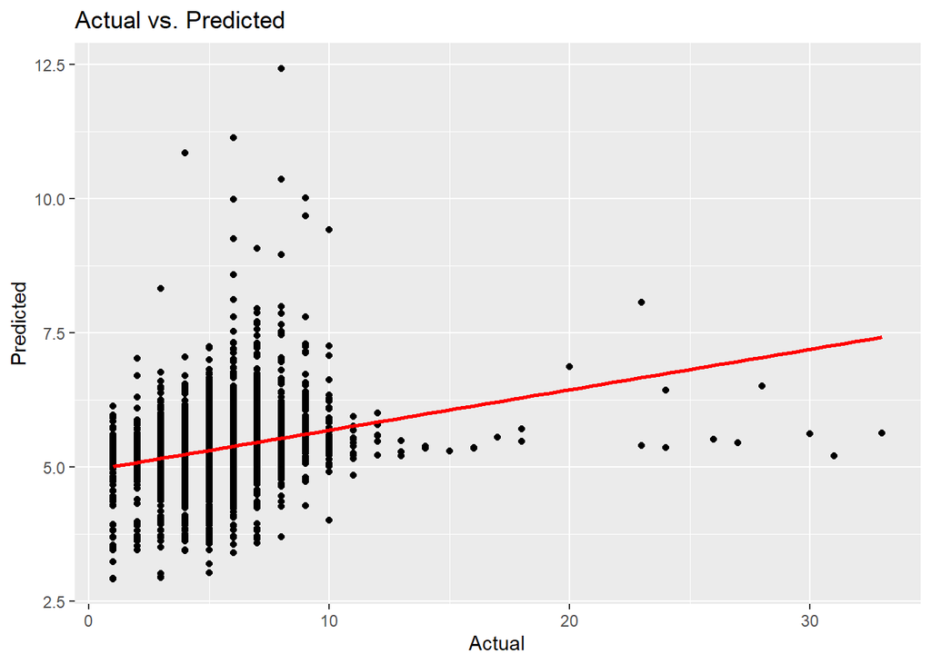

```r
library(ggplot2)
results = data.frame(actual = test_3$num_trending_days, predicted = pred4)
ggplot(results, aes(x = actual, y = predicted)) +
  geom_point() +
  xlab("Actual") +
  ylab("Predicted") +
  ggtitle("Actual vs. Predicted") +
  geom_smooth(method = "lm", se = FALSE, color = "red")
```

Then we want to get the top 20 most significant predictors (all with p-value < 0.05).

```r
library(dplyr)
library(tibble)
# Get coefficients and p-values
coef_table = summary(lm_model4)$coefficients %>%
  as.data.frame() %>%
  rownames_to_column(var = "variable") %>%
  select(variable, Estimate, `Pr(>|t|)`) %>%
  rename(coeff = Estimate, pvalue = `Pr(>|t|)`)

# Filter top 20 most significant coefficients
# can change the number inside to any number you want

top_coef = coef_table %>%
  filter(pvalue < 0.05) %>%
  arrange(pvalue) %>%
  head(20) %>%
  arrange(variable)

# Print top 20 most significant coefficients
top_coef
```

```
##                                        variable         coeff       pvalue
## 1                                   (Intercept)  5.431673e+00 0.000000e+00
## 2                               category_Gaming -3.214167e-01 1.091697e-17
## 3                                category_Music -2.377860e-01 6.409146e-07
## 4                       category_People...Blogs -2.530427e-01 2.822788e-09
## 5                               category_Sports -4.691597e-01 2.924373e-23
## 6                             channel_BLACKPINK -1.501096e+00 6.784689e-08
## 7                                channel_BWF.TV -1.347098e+00 1.666706e-07
## 8                          channel_Dude.Perfect  1.605429e+00 2.020417e-14
## 9                            channel_FOX.Soccer -1.670778e+00 5.254505e-10
## 10                 channel_Marvel.Entertainment  1.064402e+00 6.435041e-06
## 11                                  channel_NBA -9.597399e-01 3.210464e-12
## 12                           channel_NBC.Sports -1.019612e+00 1.229818e-06
## 13                         channel_SSSniperWolf -7.831213e-01 7.767226e-06
## 14                              channel_SSundee -7.823628e-01 1.184471e-05
## 15                   channel_The.Game.Theorists  1.205635e+00 5.198181e-08
## 16 channel_UFC...Ultimate.Fighting.Championship -1.095091e+00 1.346857e-06
## 17                              likes_first_day  1.445463e-06 1.165336e-84
## 18                                      tag_BTS -1.097445e+00 6.341342e-13
## 19                                  tag_science  5.686834e-01 3.515087e-06
## 20                                     tf_short -5.809625e-01 1.367671e-19
```

#### Method 3: use Ridge or Lasso regression

```r
# Method 3: use Ridge or Lasso regression
library(glmnet)
```

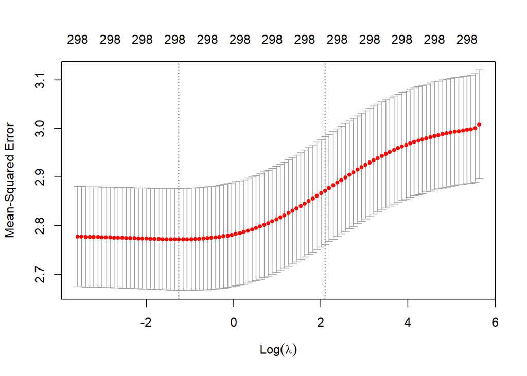

```r
X = model.matrix(num_trending_days~., data = train_3)
y = train_3$num_trending_days
#summary(model1.ridge)

# Perform cross-validation to select lambda
cv.ridge <- cv.glmnet(X, y, alpha=0) # rigde regression
cv.lasso <- cv.glmnet(X, y, alpha=1) # lasso regression

# Plot cross-validation results
plot(cv.ridge)
```

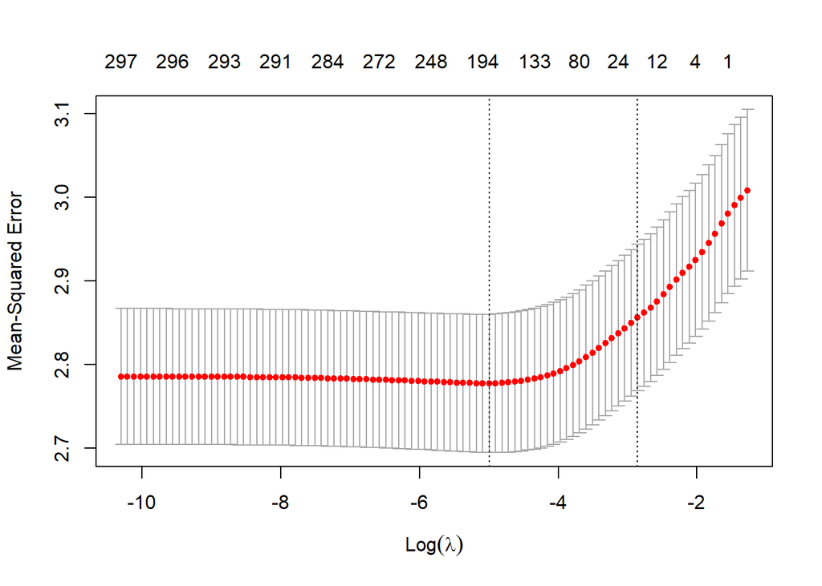

```r
plot(cv.lasso)
```

```r
# Extract optimal lambda values
lambda.ridge <- cv.ridge$lambda.min
lambda.lasso <- cv.lasso$lambda.min

# Fit final models using optimal lambda values
fit.ridge <- glmnet(X, y, alpha=0, lambda=lambda.ridge)
fit.lasso <- glmnet(X, y, alpha=1, lambda=lambda.lasso)

# Predict
test_y = test_3$num_trending_days
test_X = model.matrix(num_trending_days~., data = test_3)

# Make predictions on test set
pred.ridge <- predict(fit.ridge, newx = test_X)
pred.lasso <- predict(fit.lasso, newx = test_X)

# Calculate RMSE for each model
rmse.ridge <- sqrt(mean((pred.ridge - test_y)^2))
rmse.lasso <- sqrt(mean((pred.lasso - test_y)^2))

# Print RMSE values
cat("RMSE (ridge) = ", rmse.ridge, "\n") # 1.734175
```

```
## RMSE (ridge) =  1.734175
```

```r
cat("RMSE (lasso) = ", rmse.lasso, "\n") # 1.731986
```

```
## RMSE (lasso) =  1.731986
```

```r
# lasso works better
# lasso improved tmse best so far
```

Lasso regression has the best prediction performance so far.

##### Interpret the result from ridge and lasso regression

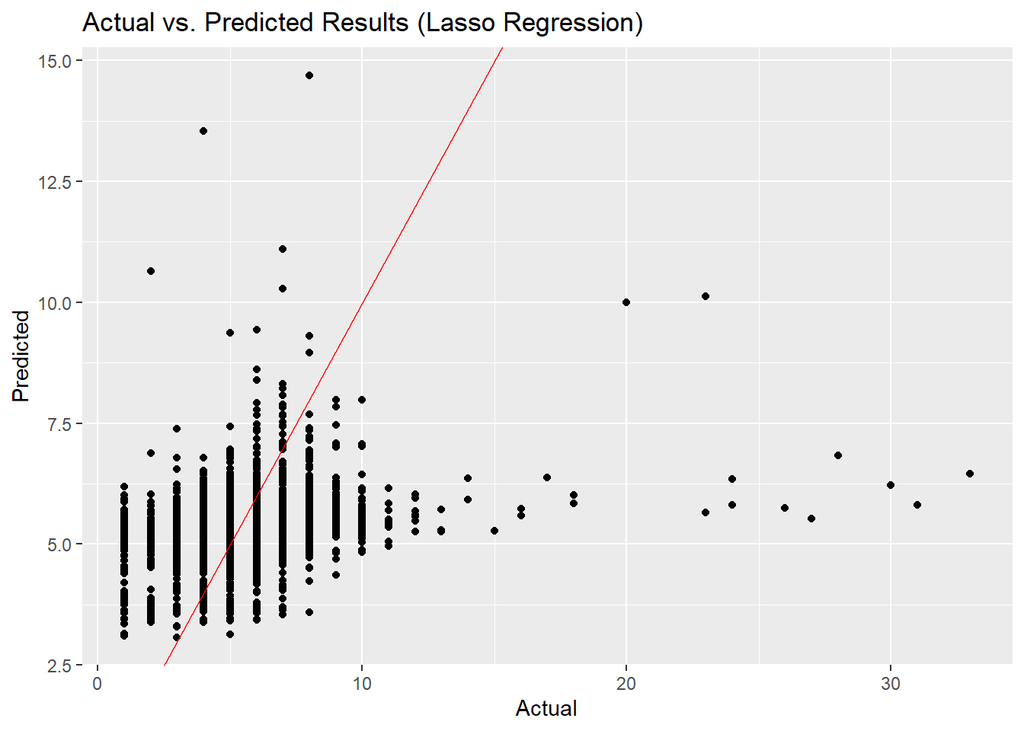

```r
library(ggplot2)

# create a data frame with actual and predicted values
df_lasso = data.frame(actual = test_y, predicted = pred.lasso)

# plot the actual versus predicted values
ggplot(df_lasso, aes(x = actual, y = s0)) +
  geom_point() +
  geom_abline(intercept = 0, slope = 1, color = "red") +
  xlab("Actual") +
  ylab("Predicted") +
  ggtitle("Actual vs. Predicted Results (Lasso Regression)")
```

```r
# coefficient values for each variables
library(dplyr)
library(tibble)

# Get coefficients and p-values
coef_table = as.matrix(round(coef(fit.lasso, s = fit.lasso$lambda.1se),4), sparse = FALSE) %>%
  as.data.frame() %>%
  rownames_to_column(var = "variable") %>%
  select(variable, s0) %>%
  rename(coeff = s0)

# Filter top coefficients with largest absolute value
# can change the number inside to any number you want

top_coef = coef_table %>%
  filter(coeff != 0) %>%
  arrange(desc(abs(coeff))) %>%
  head(20) %>%
  arrange(variable,desc(abs(coeff)))

# Print top 20 most significant coefficients
top_coef
```

```
##                                        variable   coeff
## 1                                  X.Intercept.  5.2535
## 2                category_Nonprofits...Activism  0.7371
## 3                             channel_BLACKPINK -0.8249
## 4                                channel_BWF.TV -1.1491
## 5                           channel_DAZN.Boxing  0.7914
## 6                          channel_Dude.Perfect  1.4356
## 7                            channel_FOX.Soccer -1.6311
## 8                  channel_Marvel.Entertainment  0.6803
## 9                            channel_NBC.Sports -0.5783
## 10                               channel_SMTOWN -0.8200
## 11                              channel_SSundee -0.7195
## 12                               channel_SpaceX -0.5606
## 13                   channel_The.Film.Theorists  0.4840
## 14                   channel_The.Game.Theorists  0.9616
## 15 channel_UFC...Ultimate.Fighting.Championship -0.9766
## 16                      channel_beIN.SPORTS.USA  0.5232
## 17                                      tag_BTS -0.7540
## 18                                 tag_G.League -1.0956
## 19                              tag_sniper.wolf -0.8006
## 20                                     tf_short -0.5798
```

```r
# Print variables with coefficients forced to 0 in lasso regression
zero_coef = coef_table %>%
  filter(coeff == 0) %>%
  arrange(variable)
nrow(zero_coef)
```

```
## [1] 117
```

```r
head(zero_coef)
```

```
##                    variable coeff
## 1            X.Intercept..1     0
## 2 category_Autos...Vehicles     0
## 3    channel_Clash.of.Clans     0
## 4            channel_DanTDM     0
## 5              channel_ESPN     0
## 6           channel_ESPN.FC     0
```

Bar plot:

First define a function with input of coef_table (coefficient table), coef_name (the type of coefficient start with certain name), top, bot to be the top and bottom number of variables we want to show.

```r
library(stringr)
library(ggplot2)
library(dplyr)
library(forcats)

plot_coefficients <- function(coef_table, coef_name, top = 5, bot = 5) {
  # Create table of coefficients starting with specified coefficient name
  coef <- coef_table %>%
    filter(coeff != 0) %>%
    filter(str_detect(variable, str_c("^", coef_name))) %>%
    arrange(desc(coeff))

  # Select top and bottom coefficients based on input arguments
  coef_top <- head(coef, top)
  coef_bot <- tail(coef, bot)

  # Combine top and bottom coefficients and create bar plot
  coef_plot <- rbind(coef_top, coef_bot)
  coef_plot$variable <- fct_reorder(coef_plot$variable, coef_plot$coeff, .desc = FALSE) # Reorder
  bar_plot <- ggplot(coef_plot, aes(x = variable, y = coeff, fill = coeff < 0)) +
    geom_col() +
    scale_fill_manual(values = c("blue", "orange"), labels = c("Positive", "Negative")) +
    coord_flip() +
    labs(x = "Variable", y = "Coefficient", fill = "Sign") +
    ggtitle(str_c("Top and Bottom Coefficients for ", coef_name, " Variables")) +
    theme_bw()

  # Display bar plot
  print(bar_plot)

  # Return and output the coefficient table
  return(coef_plot)
}
```

then make plots for category variables:

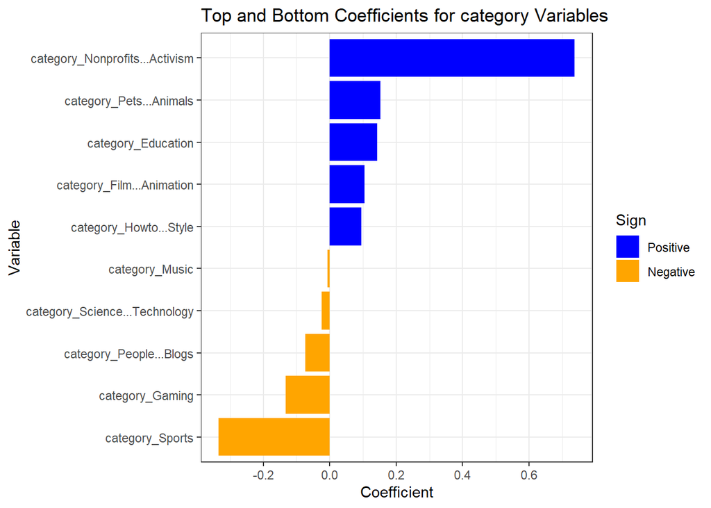

```
##                          variable   coeff
## 1  category_Nonprofits...Activism  0.7371
## 2         category_Pets...Animals  0.1529
## 3              category_Education  0.1426
## 4       category_Film...Animation  0.1042
## 5          category_Howto...Style  0.0950
## 9                  category_Music -0.0060
## 10  category_Science...Technology -0.0249
## 11        category_People...Blogs -0.0729
## 12                category_Gaming -0.1331
## 13                category_Sports -0.3345
```

```r
plot_coefficients(coef_table, "category", 5, 5)
```

then make plots for tag variables:

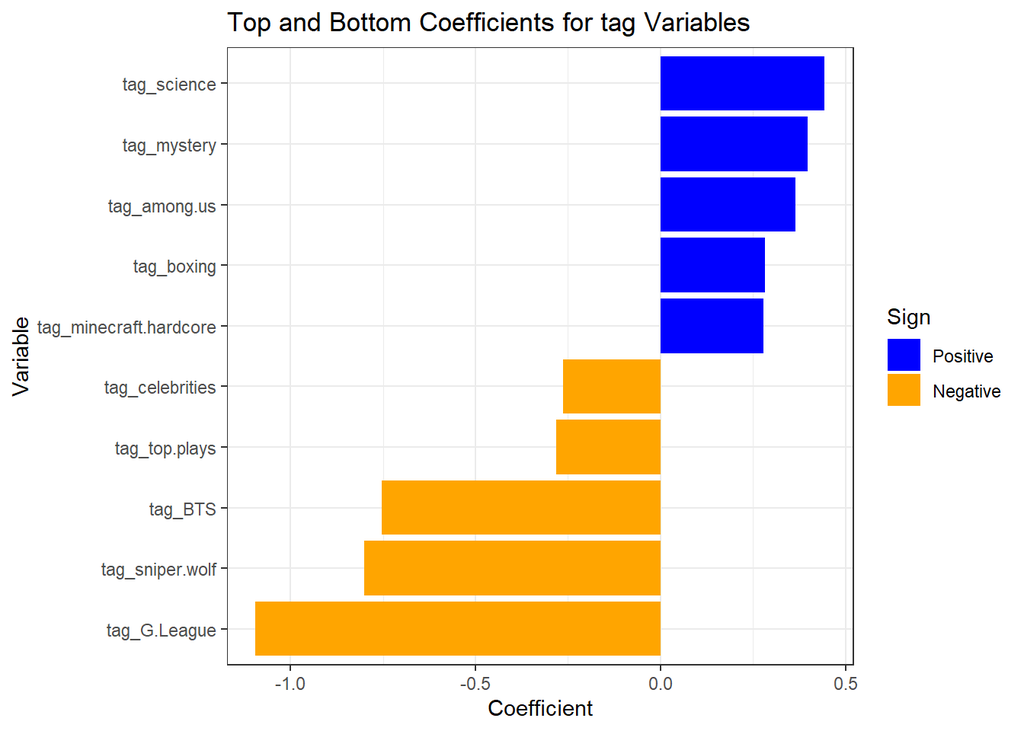

```
##                   variable   coeff
## 1              tag_science  0.4441
## 2              tag_mystery  0.3976
## 3             tag_among.us  0.3649
## 4               tag_boxing  0.2823
## 5   tag_minecraft.hardcore  0.2794
## 96         tag_celebrities -0.2623
## 97           tag_top.plays -0.2813
## 98                 tag_BTS -0.7540
## 99         tag_sniper.wolf -0.8006
## 100           tag_G.League -1.0956
```

```r
plot_coefficients(coef_table, "tag", 5, 5)
```

then make plots for channel variables:

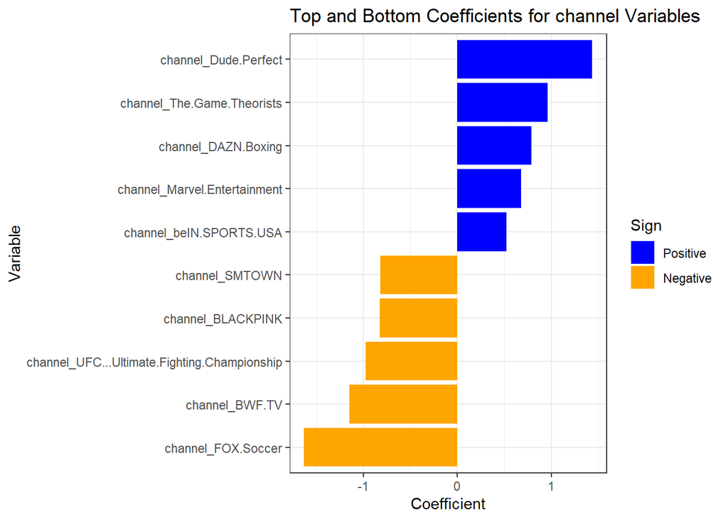

```
##                                        variable   coeff
## 1                          channel_Dude.Perfect  1.4356
## 2                    channel_The.Game.Theorists  0.9616
## 3                           channel_DAZN.Boxing  0.7914
## 4                  channel_Marvel.Entertainment  0.6803
## 5                       channel_beIN.SPORTS.USA  0.5232
## 32                               channel_SMTOWN -0.8200
## 33                            channel_BLACKPINK -0.8249
## 34 channel_UFC...Ultimate.Fighting.Championship -0.9766
## 35                               channel_BWF.TV -1.1491
## 36                           channel_FOX.Soccer -1.6311
```

```r
plot_coefficients(coef_table, "channel", 5, 5)
```

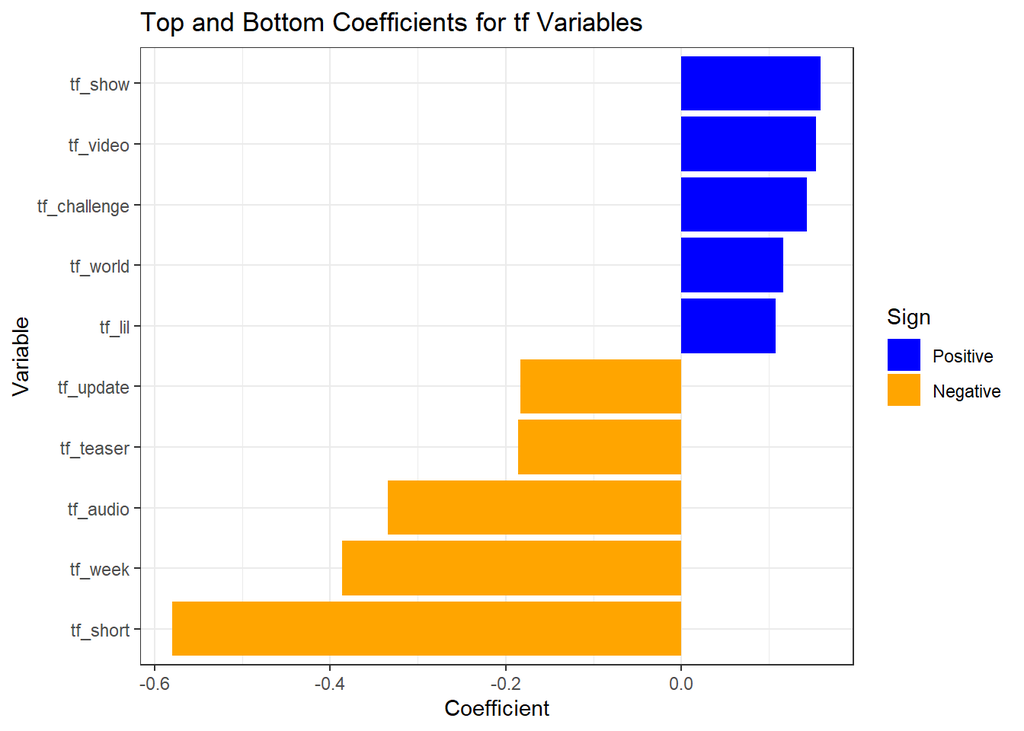

```
##        variable   coeff
## 1       tf_show  0.1592
## 2      tf_video  0.1539
## 3  tf_challenge  0.1435
## 4      tf_world  0.1167
## 5        tf_lil  0.1077
## 29    tf_update -0.1830
## 30    tf_teaser -0.1856
## 31     tf_audio -0.3342
## 32      tf_week -0.3865
## 33     tf_short -0.5798
```

```r
plot_coefficients(coef_table, "tf", 5, 5)
```

## Tree & Random Forest

```r
# tree
library(rpart); library(rpart.plot)
tree.fit1 = rpart(model_removed_1,data = train_3, method = 'anova')
pred_tree1 = predict(tree.fit1, newdata = test_3)
rmse_tree1 = sqrt(mean((pred_tree1 - test_3$num_trending_days)^2)); rmse_tree1
```

```
## [1] 1.766565
```

```r
# 1.766565

# randomforest
library(ranger)
set.seed(1031)
forest_ranger_1 = ranger(model_removed_1,
                       data = train_3,
                       num.trees = 500,
                       seed = 617)

pred_1 = predict(forest_ranger_1, data = test_3, num.trees = 500)
rmse_forest_ranger_1 = sqrt(mean((pred_1$predictions - test_3$num_trending_days)^2)); rmse_forest_ranger_1
```

```
## [1] 1.653836
```

```r
# 1.653836
# improved, best
# plot(test_3$num_trending_days,pred$predictions)
forest_ranger_2 = ranger(model_removed_1,
                       data = train_3,
                       mtry = sqrt(ncol(train_3) - 1),
                       importance = 'impurity',
                       num.trees = 500,
                       seed = 617)

pred_2 = predict(forest_ranger_2, data = test_3, num.trees = 500)
rmse_forest_ranger_2 = sqrt(mean((pred_2$predictions - test_3$num_trending_days)^2)); rmse_forest_ranger_2
```

```
## [1] 1.65289
```

```r
# 1.65289

# get the importance of variables in variables
importance_variables = data.frame(forest_ranger_2$variable.importance)
colnames(importance_variables)
```

```
## [1] "forest_ranger_2.variable.importance"
```

```r
importance_variables %>% arrange(desc(forest_ranger_2.variable.importance)) %>% head(20)
```

```
##                          forest_ranger_2.variable.importance
## comment_count_first_day                            6912.7089
## likes_first_day                                    5982.9213
## dislikes_first_day                                 3099.3003
## category_News...Politics                            589.2318
## tag_2022                                            571.0456
## category_Entertainment                              521.8729
## tag_the                                             498.6661
## category_Sports                                     488.4294
## tf_highlight                                        394.6348
## tag_2021                                            370.1919
## tag_video                                           345.9244
## tag_new                                             323.9573
## tag_NoTag                                           321.7770
## category_Music                                      289.6554
## channel_NFL                                         282.7730
## tf_official                                         280.4234
## tag_Highlights                                      279.9733
## tag_live                                            276.3235
## tf_video                                            271.3200
## tag_fun                                             266.1733
```

plot the best random forest results:

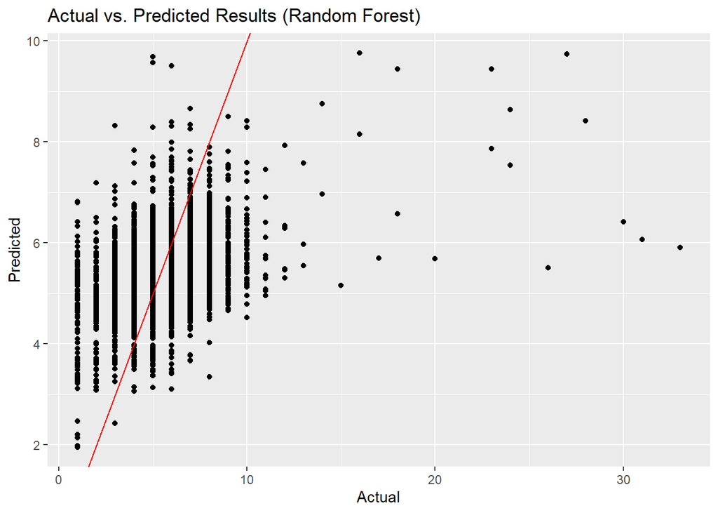

```r
# create a data frame with actual and predicted values
df_forest = data.frame(actual = test_3$num_trending_days, predicted = pred_2$predictions)

# plot the actual versus predicted values
ggplot(df_forest, aes(x = actual, y = predicted)) +
  geom_point() +
  geom_abline(intercept = 0, slope = 1, color = "red") +
  xlab("Actual") +
  ylab("Predicted") +
  ggtitle("Actual vs. Predicted Results (Random Forest)")
```

The following is the process we do tuning random forest and fit the best tuned model. As it does not works better than forest_ranger_2, we mute them and not include in our report.

```r
# variable importances using
# # tuned random forest with ranger, this would take too much time
# library(caret)
# trControl=trainControl(method="cv",number=3)
# tuneGrid = expand.grid(mtry=floor(ncol(train_3) * c(0.1,0.25,0.3)),
#                        splitrule = c('extratrees','maxstat'),
#                        min.node.size = c(5,15,30))
# set.seed(1031)
# cvModel = train(model_removed_1,
#                 data=train_3,
#                 method="ranger",
#                 num.trees=100,
#                 trControl=trControl,
#                 tuneGrid=tuneGrid)
# cvModel$bestTune
# mtry  splitrule min.node.size
# 9   75 extratrees            30

# forest_ranger_3 = ranger(model_removed_1,
#                        data = train_3,
#                        mtry = 75,
#                        importance = 'impurity',
#                        num.trees = 500,
#                        splitrule = 'extratrees',
#                        min.node.size = 30,
#                        seed = 617)
#
# pred_3 = predict(forest_ranger_3, data = test_3, num.trees = 500)
# rmse_forest_ranger_3 = sqrt(mean((pred_3$predictions - test_3$num_trending_days)^2)); rmse_forest_ranger_3
# 1.667928
```

Random Forest has the best prediction performance with the lowest RMSE

## Single Layer Neural Network

We tried single layer neural Networks on the former 3 models we built.

```r
library(nnet)
# scaling
maxs = apply(data_3, 2, max)
mins = apply(data_3, 2, min)
scaled = as.data.frame(scale(data_3, center = mins, scale = maxs - mins))
train_scaled = scaled[split_3,]
train_scaled$num_trending_days = train_3$num_trending_days
test_scaled = scaled[-split_3,]
test_scaled$num_trending_days = test_3$num_trending_days

#train_scaled$num_trending_days

# Set up the neural network model
set.seed(617)
model_nn_1 = nnet(model_removed_1, data = train_scaled, size = 1, linout = TRUE)
# Make predictions on the test set
predictions_1 = predict(model_nn_1, newdata = test_scaled)

# Calculate the RMSE of the predictions
rmse_nn_1 = sqrt(mean((predictions_1 - test_scaled$num_trending_days)^2))
rmse_nn_1
```

```
## [1] 1.734341
```

```r
# plot(test_scaled$num_trending_days,predictions_1)
# worse than random forest

set.seed(617)
model_nn_2 = nnet(model_removed_2, data = train_scaled, size = 1, linout = TRUE)
# Make predictions on the test set
predictions_2 = predict(model_nn_2, newdata = test_scaled)

# Calculate the RMSE of the predictions
rmse_nn_2 = sqrt(mean((predictions_2 - test_scaled$num_trending_days)^2))
rmse_nn_2
```

```
## [1] 1.717561
```

```r
# Set up the neural network model
set.seed(617)
model_nn_3 = nnet(model_removed_3, data = train_scaled, size = 1, linout = TRUE)
# Make predictions on the test set
predictions_3 = predict(model_nn_3, newdata = test_scaled)

# Calculate the RMSE of the predictions
rmse_nn_3 = sqrt(mean((predictions_3 - test_scaled$num_trending_days)^2))
rmse_nn_3
```

```
## [1] 1.719164
```

### Interpret the best neural network

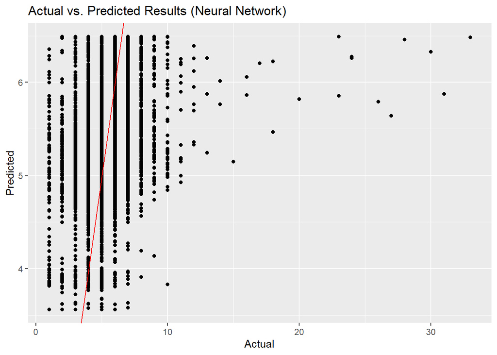

```r
# create a data frame with actual and predicted values
df_nn = data.frame(actual = test_scaled$num_trending_days, predicted = predictions_2)

# plot the actual versus predicted values
ggplot(df_nn, aes(x = actual, y = predicted)) +
  geom_point() +
  geom_abline(intercept = 0, slope = 1, color = "red") +
  xlab("Actual") +
  ylab("Predicted") +
  ggtitle("Actual vs. Predicted Results (Neural Network)")
```

# III. Lasso Regression on different years

```r
# append years column to data_3
dim(data_3) # 34218   299
```

```
## [1] 34218   299
```

```r
dim(data_clean) # 34218    14
```

```
## [1] 34218    14
```

```r
data_3_years = cbind(data_clean$published_year,data_3)
colnames(data_3_years)[1] = "published_year"
table(data_3_years$published_year)
```

```
##
##  2020  2021  2022  2023
##  5161 13378 13775  1904
```

```r
# divide different years data

data_2020 =  data_3_years[data_3_years$published_year=="2020",]
dim(data_2020) # 5161  300
```

```
## [1] 5161  300
```

```r
data_2021 =  data_3_years[data_3_years$published_year=="2021",]
dim(data_2021) # 13378   300
```

```
## [1] 13378   300
```

```r
data_2022 =  data_3_years[data_3_years$published_year=="2022",]
dim(data_2022) # 13775   300
```

```
## [1] 13775   300
```

```r
data_2023 =  data_3_years[data_3_years$published_year=="2023",]
dim(data_2023) # 1904  300
```

```
## [1] 1904  300
```

```r
# train and test set

set.seed(617)
split_2020 = sample(1:nrow(data_2020), nrow(data_2020)*0.80)
train_2020 = data_2020[split_2020,]
test_2020 = data_2020[-split_2020,]
dim(train_2020)
```

```
## [1] 4128  300
```

```r
# For data_2021
set.seed(617)
split_2021 <- sample(1:nrow(data_2021), nrow(data_2021) * 0.80)
train_2021 <- data_2021[split_2021,]
test_2021 <- data_2021[-split_2021,]
dim(train_2021)
```

```
## [1] 10702   300
```

```r
# For data_2022
set.seed(617)
split_2022 <- sample(1:nrow(data_2022), nrow(data_2022) * 0.80)
train_2022 <- data_2022[split_2022,]
test_2022 <- data_2022[-split_2022,]
dim(train_2022)
```

```
## [1] 11020   300
```

```r
# For data_2023
set.seed(617)
split_2023 <- sample(1:nrow(data_2023), nrow(data_2023) * 0.80)
train_2023 <- data_2023[split_2023,]
test_2023 <- data_2023[-split_2023,]
dim(train_2023)
```

```
## [1] 1523  300
```

For 2020:

```r
# Fit lasso regression
# Method 3:  Lasso regression
library(glmnet)
X_2020 = model.matrix(num_trending_days~.-published_year, data = train_2020)
y_2020 = train_2020$num_trending_days

cv.lasso_2020 <- cv.glmnet(X_2020, y_2020, alpha=1)

fit.lasso_2020 <- glmnet(X_2020, y_2020, alpha=1, lambda=cv.lasso_2020$lambda.min)

test_y_2020 = test_2020$num_trending_days
test_X_2020 = model.matrix(num_trending_days~.-published_year, data = test_2020)

pred.lasso_2020 <- predict(fit.lasso_2020, newx = test_X_2020)

rmse.lasso_2020 <- sqrt(mean((pred.lasso_2020 - test_y_2020)^2));rmse.lasso_2020
```

```
## [1] 1.792611
```

```r
# coef(fit.lasso_2020, s = fit.lasso_2020$lasso.1se) %>%
#   round(4) %>% head()
```

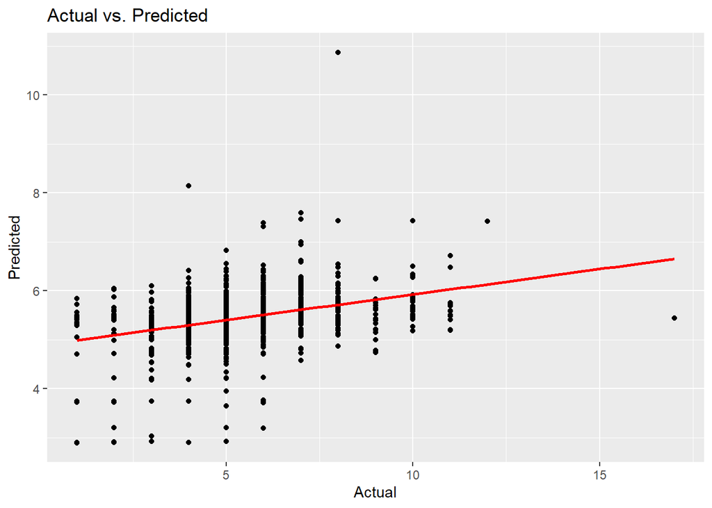

```r
results = data.frame(actual = test_2020$num_trending_days, predicted = pred.lasso_2020)
ggplot(results, aes(x = actual, y = s0)) +
  geom_point() +
  xlab("Actual") +
  ylab("Predicted") +
  ggtitle("Actual vs. Predicted") +
  geom_smooth(method = "lm", se = FALSE, color = "red")
```

```r
# Get coefficients and p-values
coef_table = as.matrix(round(coef(fit.lasso_2020, s = fit.lasso_2020$lambda.1se),4), sparse = FALSE) %>%
  as.data.frame() %>%
  rownames_to_column(var = "variable") %>%
  select(variable, s0) %>%
  rename(coeff = s0)

# Filter top coefficients with largest absolute value
# can change the number inside to any number you want

top_coef = coef_table %>%
  filter(coeff != 0) %>%
  arrange(desc(abs(coeff))) %>%
  head(20) %>%
  arrange(variable,desc(abs(coeff)))

# Print top 20 most significant coefficients
top_coef
```

```
##                      variable   coeff
## 1                X.Intercept.  5.4145
## 2        channel_Apex.Legends  0.7560
## 3           channel_BANGTANTV -0.5728
## 4         channel_DAZN.Boxing  0.9348
## 5        channel_Dude.Perfect  1.4461
## 6                 channel_NFL -0.9697
## 7              channel_SpaceX -0.5262
## 8  channel_The.Film.Theorists  0.5756
## 9          channel_Veritasium  0.4997
## 10    channel_beIN.SPORTS.USA  0.7709
## 11                    tag_BTS -0.5545
## 12               tag_G.League -0.5555
## 13              tag_Minecraft  0.4649
## 14             tag_experiment  0.5859
## 15               tag_lil.durk  0.5341
## 16               tag_trolling  1.9727
## 17                    tf_best  0.8341
## 18                    tf_game -0.5609
## 19               tf_highlight -0.4804
## 20                  tf_update -0.7238
```

```r
# Print variables with coefficients forced to 0 in lasso regression
zero_coef = coef_table %>%
  filter(coeff == 0) %>%
  arrange(variable)
nrow(zero_coef)
```

```
## [1] 201
```

```r
head(zero_coef)
```

```
##                    variable coeff
## 1            X.Intercept..1     0
## 2 category_Autos...Vehicles     0
## 3           category_Comedy     0
## 4    category_Entertainment     0
## 5 category_Film...Animation     0
## 6           category_Gaming     0
```

then make plots for category variables:

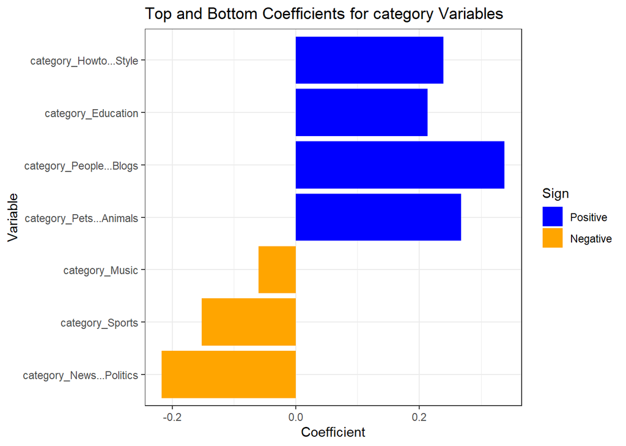

```
##                    variable   coeff
## 1    category_Howto...Style  0.2390
## 2        category_Education  0.2135
## 3   category_People...Blogs  0.1689
## 4   category_Pets...Animals  0.1339
## 5            category_Music -0.0299
## 31  category_People...Blogs  0.1689
## 41  category_Pets...Animals  0.1339
## 51           category_Music -0.0299
## 6           category_Sports -0.1525
## 7  category_News...Politics -0.2167
```

```r
plot_coefficients(coef_table, "category", 5, 5)
```

then make plots for tag variables:

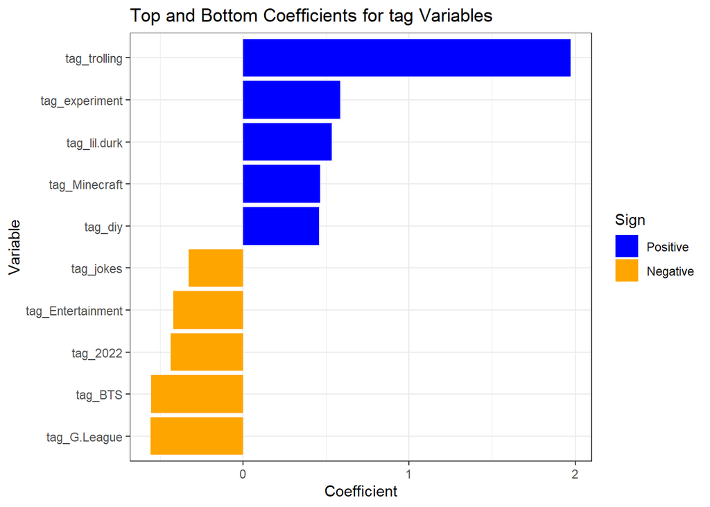

```
##             variable   coeff
## 1       tag_trolling  1.9727
## 2     tag_experiment  0.5859
## 3       tag_lil.durk  0.5341
## 4      tag_Minecraft  0.4649
## 5            tag_diy  0.4571
## 56         tag_jokes -0.3289
## 57 tag_Entertainment -0.4204
## 58          tag_2022 -0.4354
## 59           tag_BTS -0.5545
## 60      tag_G.League -0.5555
```

```r
plot_coefficients(coef_table, "tag", 5, 5)
```

then make plots for channel variables:

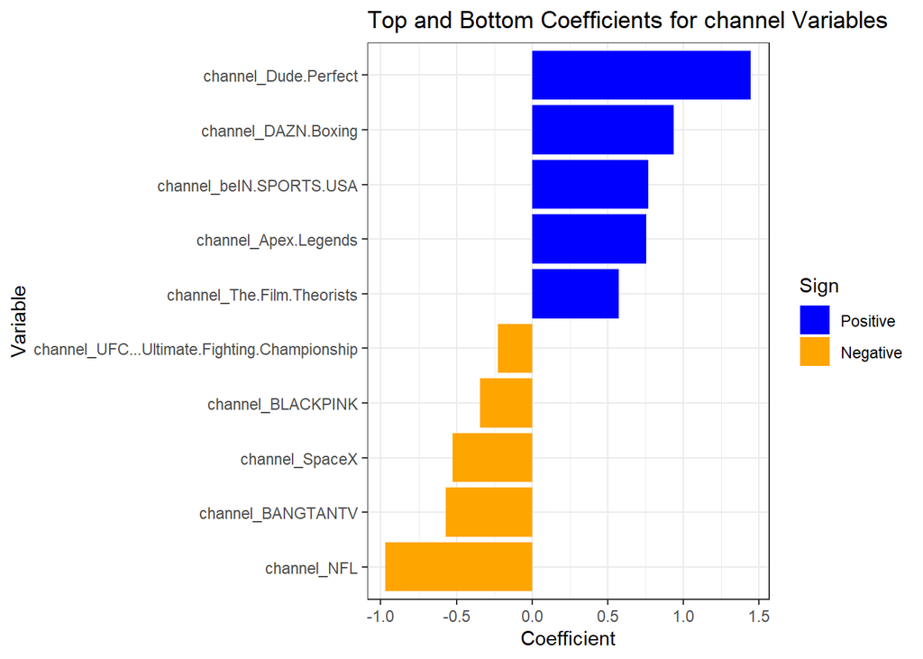

```
##                                        variable   coeff
## 1                          channel_Dude.Perfect  1.4461
## 2                           channel_DAZN.Boxing  0.9348
## 3                       channel_beIN.SPORTS.USA  0.7709
## 4                          channel_Apex.Legends  0.7560
## 5                    channel_The.Film.Theorists  0.5756
## 11 channel_UFC...Ultimate.Fighting.Championship -0.2279
## 12                            channel_BLACKPINK -0.3460
## 13                               channel_SpaceX -0.5262
## 14                            channel_BANGTANTV -0.5728
## 15                                  channel_NFL -0.9697
```

```r
plot_coefficients(coef_table, "channel", 5, 5)
```

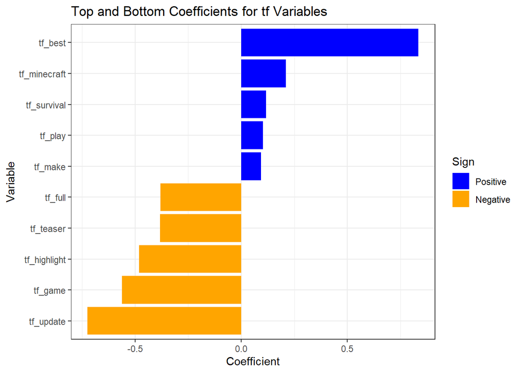

```
##        variable   coeff
## 1       tf_best  0.8341
## 2  tf_minecraft  0.2103
## 3   tf_survival  0.1164
## 4       tf_play  0.1015
## 5       tf_make  0.0929
## 12      tf_full -0.3800
## 13    tf_teaser -0.3813
## 14 tf_highlight -0.4804
## 15      tf_game -0.5609
## 16    tf_update -0.7238
```

```r
plot_coefficients(coef_table, "tf", 5, 5)
```

For year 2021:

```r
library(glmnet)
X_2021 <- model.matrix(num_trending_days ~ . - published_year, data = train_2021)
y_2021 <- train_2021$num_trending_days

cv.lasso_2021 <- cv.glmnet(X_2021, y_2021, alpha = 1)

fit.lasso_2021 <- glmnet(X_2021, y_2021, alpha = 1, lambda = cv.lasso_2021$lambda.min)

test_y_2021 <- test_2021$num_trending_days
test_X_2021 <- model.matrix(num_trending_days ~ . - published_year, data = test_2021)

pred.lasso_2021 <- predict(fit.lasso_2021, newx = test_X_2021)

rmse.lasso_2021 <- sqrt(mean((pred.lasso_2021 - test_y_2021)^2)); rmse.lasso_2021
```

```
## [1] 1.627781
```

```r
# Get coefficients and p-values
coef_table = as.matrix(round(coef(fit.lasso_2021, s = fit.lasso_2021$lambda.1se),4), sparse = FALSE) %>%
  as.data.frame() %>%
  rownames_to_column(var = "variable") %>%
  select(variable, s0) %>%
  rename(coeff = s0)

# Filter top coefficients with largest absolute value
# can change the number inside to any number you want

top_coef = coef_table %>%
  filter(coeff != 0) %>%
  arrange(desc(abs(coeff))) %>%
  head(20) %>%
  arrange(variable,desc(abs(coeff)))

# Print top 20 most significant coefficients
top_coef
```

```
##                                        variable   coeff
## 1                                  X.Intercept.  5.3583
## 2                             channel_BLACKPINK -1.5178
## 3                                channel_BWF.TV -1.2985
## 4                           channel_DAZN.Boxing  1.3574
## 5                          channel_Dude.Perfect  0.4860
## 6                     channel_JYP.Entertainment -0.4838
## 7                               channel_MrBeast  0.4819
## 8                        channel_MrBeast.Gaming  0.5117
## 9                            channel_NBC.Sports -0.6311
## 10                          channel_Ryan.Trahan  0.5107
## 11                               channel_SMTOWN -0.5021
## 12                              channel_SSundee -0.6618
## 13                   channel_The.Game.Theorists  0.5622
## 14 channel_UFC...Ultimate.Fighting.Championship -0.8545
## 15                                      tag_BTS -1.3895
## 16                                      tag_NBC -0.4416
## 17                           tag_minecraft.mods -0.4761
## 18                             tag_sssniperwolf -0.5159
## 19                                     tf_audio -0.5531
## 20                                     tf_short -0.5124
```

```r
# Print variables with coefficients forced to 0 in lasso regression
zero_coef = coef_table %>%
  filter(coeff == 0) %>%
  arrange(variable)
nrow(zero_coef)
```

```
## [1] 160
```

```r
head(zero_coef)
```

```
##                        variable coeff
## 1                X.Intercept..1     0
## 2     category_Autos...Vehicles     0
## 3            category_Education     0
## 4        category_Entertainment     0
## 5                category_Music     0
## 6 category_Science...Technology     0
```

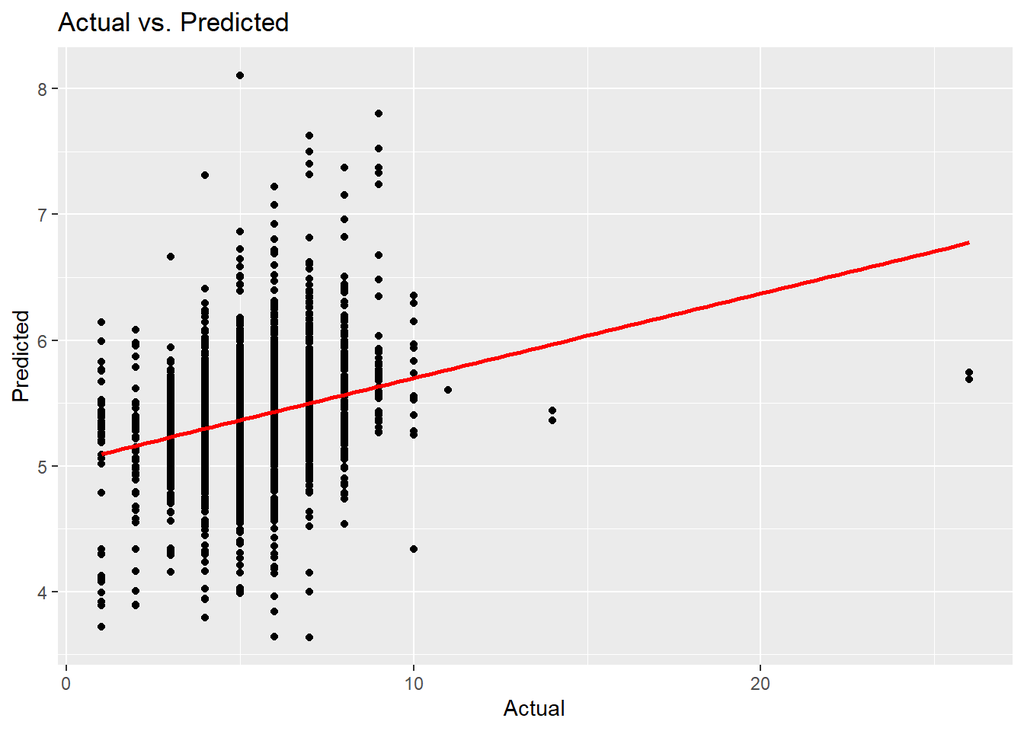

```r
results = data.frame(actual = test_2021$num_trending_days, predicted = pred.lasso_2021)
ggplot(results, aes(x = actual, y = s0)) +
  geom_point() +
  xlab("Actual") +
  ylab("Predicted") +
  ggtitle("Actual vs. Predicted") +
  geom_smooth(method = "lm", se = FALSE, color = "red")
```

then make plots for category variables:

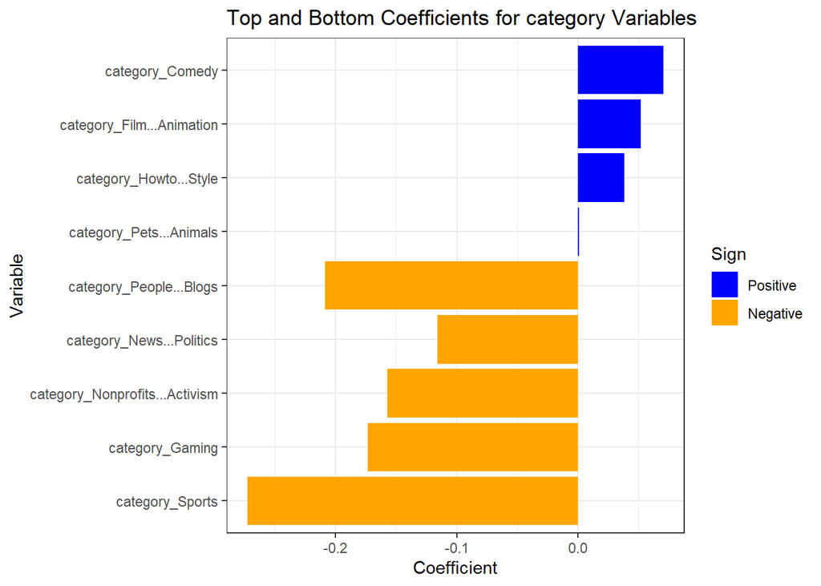

```
##                          variable   coeff
## 1                 category_Comedy  0.0703
## 2       category_Film...Animation  0.0519
## 3          category_Howto...Style  0.0382
## 4         category_Pets...Animals  0.0009
## 5         category_People...Blogs -0.1043
## 51        category_People...Blogs -0.1043
## 6        category_News...Politics -0.1157
## 7  category_Nonprofits...Activism -0.1572
## 8                 category_Gaming -0.1731
## 9                 category_Sports -0.2727
```

```r
plot_coefficients(coef_table, "category", 5, 5)
```

then make plots for tag variables:

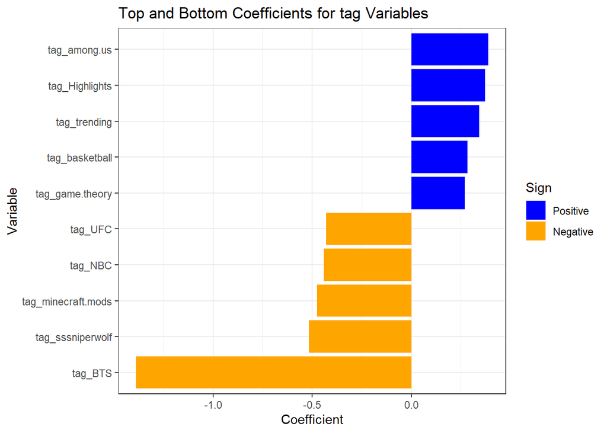

```
##              variable   coeff
## 1        tag_among.us  0.3872
## 2      tag_Highlights  0.3713
## 3        tag_trending  0.3420
## 4      tag_basketball  0.2833
## 5     tag_game.theory  0.2684
## 78            tag_UFC -0.4305
## 79            tag_NBC -0.4416
## 80 tag_minecraft.mods -0.4761
## 81   tag_sssniperwolf -0.5159
## 82            tag_BTS -1.3895
```

```r
plot_coefficients(coef_table, "tag", 5, 5)
```

then make plots for channel variables:

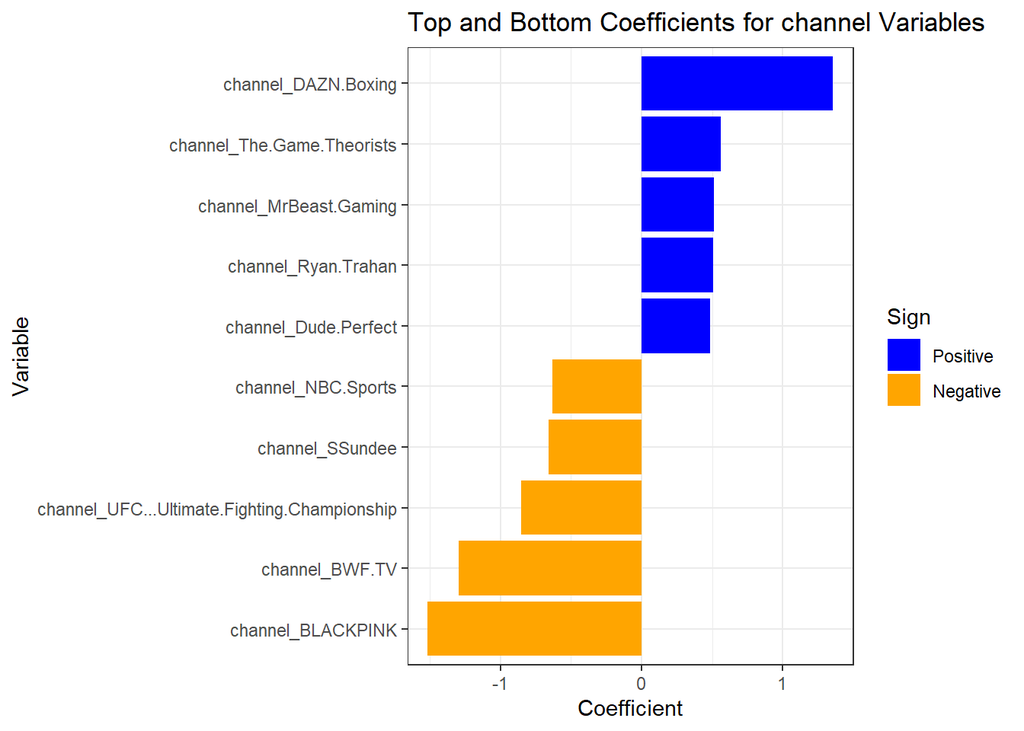

```
##                                        variable   coeff
## 1                           channel_DAZN.Boxing  1.3574
## 2                    channel_The.Game.Theorists  0.5622
## 3                        channel_MrBeast.Gaming  0.5117
## 4                           channel_Ryan.Trahan  0.5107
## 5                          channel_Dude.Perfect  0.4860
## 25                           channel_NBC.Sports -0.6311
## 26                              channel_SSundee -0.6618
## 27 channel_UFC...Ultimate.Fighting.Championship -0.8545
## 28                               channel_BWF.TV -1.2985
## 29                            channel_BLACKPINK -1.5178
```

```r
plot_coefficients(coef_table, "channel", 5, 5)
```

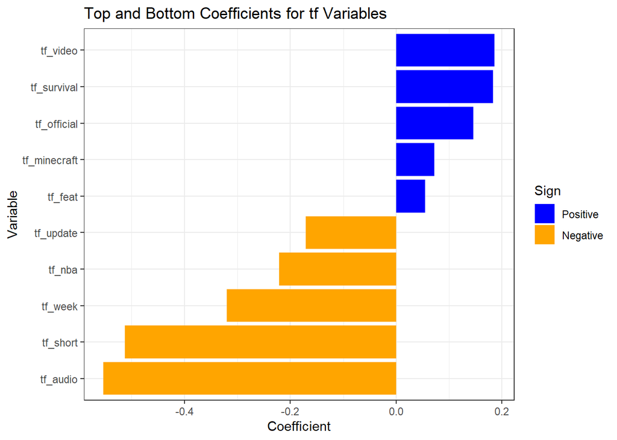

```
##        variable   coeff
## 1      tf_video  0.1859
## 2   tf_survival  0.1833
## 3   tf_official  0.1463
## 4  tf_minecraft  0.0720
## 5       tf_feat  0.0551
## 15    tf_update -0.1710
## 16       tf_nba -0.2207
## 17      tf_week -0.3196
## 18     tf_short -0.5124
## 19     tf_audio -0.5531
```

```r
plot_coefficients(coef_table, "tf", 5, 5)
```

For 2022:

```r
library(glmnet)
X_2022 <- model.matrix(num_trending_days ~ . - published_year, data = train_2022)
y_2022 <- train_2022$num_trending_days

cv.lasso_2022 <- cv.glmnet(X_2022, y_2022, alpha = 1)

fit.lasso_2022 <- glmnet(X_2022, y_2022, alpha = 1, lambda = cv.lasso_2022$lambda.min)

test_y_2022 <- test_2022$num_trending_days
test_X_2022 <- model.matrix(num_trending_days ~ . - published_year, data = test_2022)

pred.lasso_2022 <- predict(fit.lasso_2022, newx = test_X_2022)

rmse.lasso_2022 <- sqrt(mean((pred.lasso_2022 - test_y_2022)^2)); rmse.lasso_2022
```

```
## [1] 1.694102
```

```r
# Get coefficients and p-values
coef_table = as.matrix(round(coef(fit.lasso_2022, s = fit.lasso_2022$lambda.1se),4), sparse = FALSE) %>%
  as.data.frame() %>%
  rownames_to_column(var = "variable") %>%
  select(variable, s0) %>%
  rename(coeff = s0)

# Filter top coefficients with largest absolute value
# can change the number inside to any number you want

top_coef = coef_table %>%
  filter(coeff != 0) %>%
  arrange(desc(abs(coeff))) %>%
  head(20) %>%
  arrange(variable,desc(abs(coeff)))

# Print top 20 most significant coefficients
top_coef
```

```
##                                        variable   coeff
## 1                                  X.Intercept.  5.0778
## 2                category_Nonprofits...Activism 19.3104
## 3                             channel_BLACKPINK  1.3916
## 4                                channel_BWF.TV -0.8439
## 5                           channel_DAZN.Boxing  2.1903
## 6                          channel_Dude.Perfect  1.6954
## 7                            channel_FOX.Soccer -1.8799
## 8                        channel_First.We.Feast  0.5593
## 9                     channel_JYP.Entertainment -0.8558
## 10                       channel_MrBeast.Gaming  1.6743
## 11                                  channel_NFL -0.7758
## 12                          channel_Ryan.Trahan -0.6281
## 13                               channel_SMTOWN -1.5261
## 14 channel_UFC...Ultimate.Fighting.Championship -0.9708
## 15                                 tag_G.League -0.6240
## 16                                   tag_Soccer -0.6948
## 17                                    tag_jokes -0.6939
## 18                               tag_late.night  0.8511
## 19                              tag_sniper.wolf -1.2837
## 20                                     tf_short -0.5945
```

```r
# Print variables with coefficients forced to 0 in lasso regression
zero_coef = coef_table %>%
  filter(coeff == 0) %>%
  arrange(variable)
nrow(zero_coef)
```

```
## [1] 128
```

```r
head(zero_coef)
```

```
##                 variable coeff
## 1         X.Intercept..1     0
## 2         category_Music     0
## 3   channel_Apex.Legends     0
## 4   channel_Beast.Reacts     0
## 5 channel_Clash.of.Clans     0
## 6           channel_ESPN     0
```

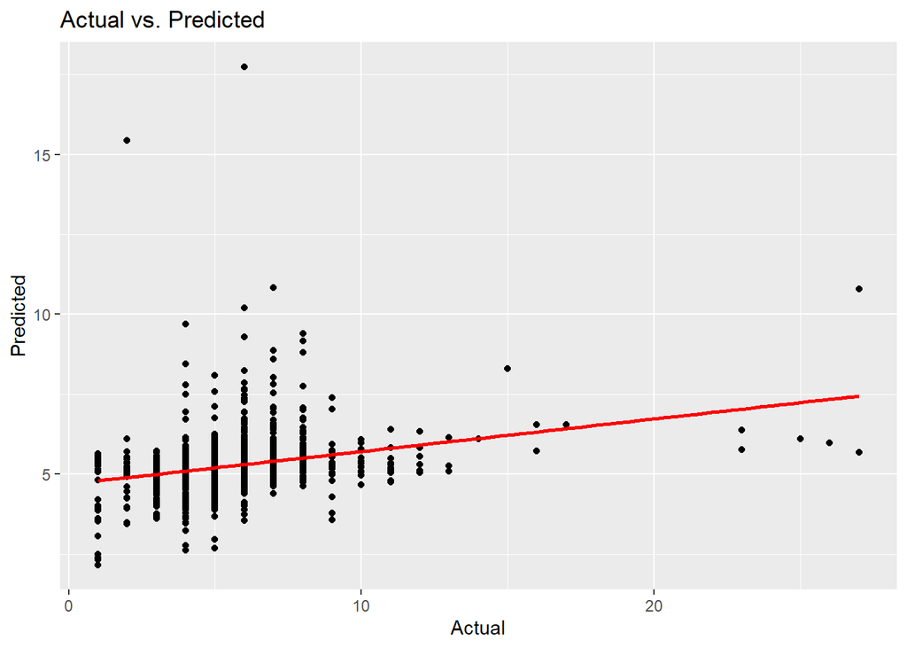

```r
results = data.frame(actual = test_2022$num_trending_days, predicted = pred.lasso_2022)
ggplot(results, aes(x = actual, y = s0)) +
  geom_point() +
  xlab("Actual") +
  ylab("Predicted") +
  ggtitle("Actual vs. Predicted") +
  geom_smooth(method = "lm", se = FALSE, color = "red")
```

then make plots for category variables:

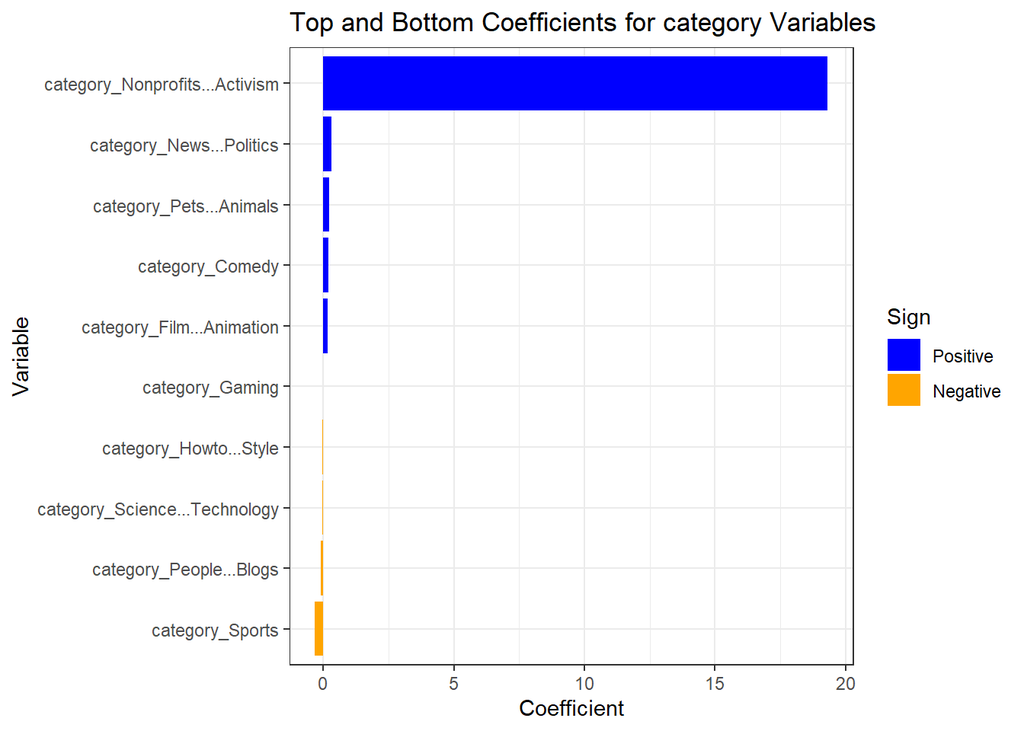

```
##                          variable   coeff
## 1  category_Nonprofits...Activism 19.3104
## 2        category_News...Politics  0.3115
## 3         category_Pets...Animals  0.2148
## 4                 category_Comedy  0.1929
## 5       category_Film...Animation  0.1710
## 9                 category_Gaming -0.0131
## 10         category_Howto...Style -0.0208
## 11  category_Science...Technology -0.0367
## 12        category_People...Blogs -0.0893
## 13                category_Sports -0.3248
```

```r
plot_coefficients(coef_table, "category", 5, 5)
```

then make plots for tag variables:

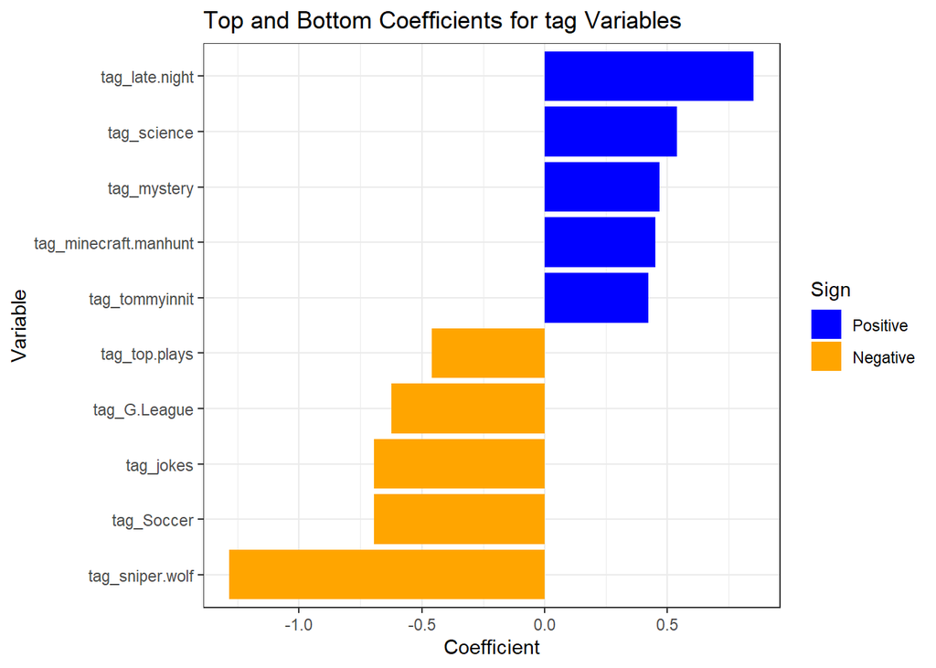

```
##                 variable   coeff
## 1         tag_late.night  0.8511
## 2            tag_science  0.5384
## 3            tag_mystery  0.4685
## 4  tag_minecraft.manhunt  0.4516
## 5         tag_tommyinnit  0.4233
## 92         tag_top.plays -0.4597
## 93          tag_G.League -0.6240
## 94             tag_jokes -0.6939
## 95            tag_Soccer -0.6948
## 96       tag_sniper.wolf -1.2837
```

```r
plot_coefficients(coef_table, "tag", 5, 5)
```

then make plots for channel variables:

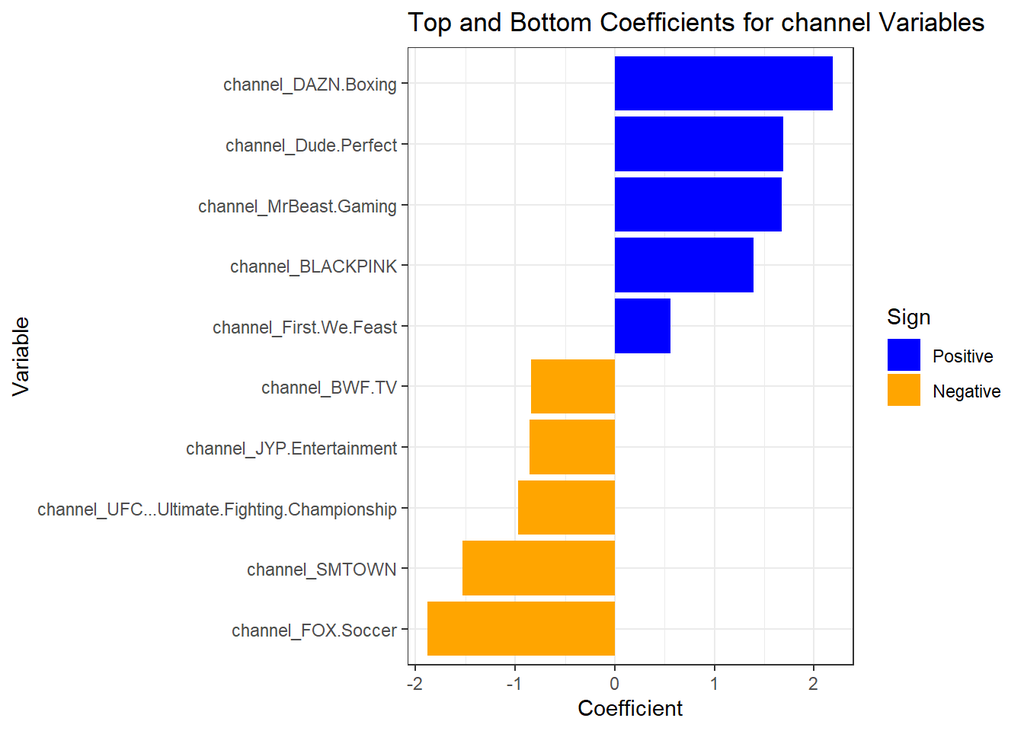

```
##                                        variable   coeff
## 1                           channel_DAZN.Boxing  2.1903
## 2                          channel_Dude.Perfect  1.6954
## 3                        channel_MrBeast.Gaming  1.6743
## 4                             channel_BLACKPINK  1.3916
## 5                        channel_First.We.Feast  0.5593
## 27                               channel_BWF.TV -0.8439
## 28                    channel_JYP.Entertainment -0.8558
## 29 channel_UFC...Ultimate.Fighting.Championship -0.9708
## 30                               channel_SMTOWN -1.5261
## 31                           channel_FOX.Soccer -1.8799
```

```r
plot_coefficients(coef_table, "channel", 5, 5)
```

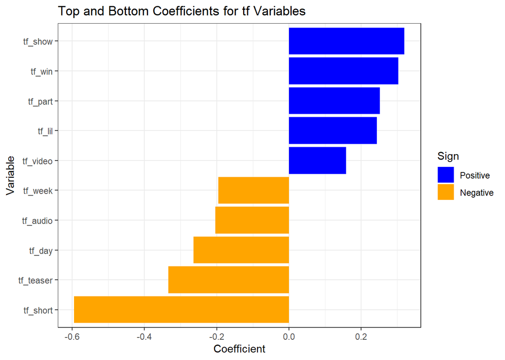

```
##     variable   coeff
## 1    tf_show  0.3196
## 2     tf_win  0.3029
## 3    tf_part  0.2521
## 4     tf_lil  0.2437
## 5   tf_video  0.1580
## 27   tf_week -0.1953
## 28  tf_audio -0.2038
## 29    tf_day -0.2638
## 30 tf_teaser -0.3341
## 31  tf_short -0.5945
```

```r
plot_coefficients(coef_table, "tf", 5, 5)
```

For 2023:

```r
library(glmnet)
X_2023 <- model.matrix(num_trending_days ~ . - published_year, data = train_2023)
y_2023 <- train_2023$num_trending_days

cv.lasso_2023 <- cv.glmnet(X_2023, y_2023, alpha = 1)

fit.lasso_2023 <- glmnet(X_2023, y_2023, alpha = 1, lambda = cv.lasso_2023$lambda.min)

test_y_2023 <- test_2023$num_trending_days
test_X_2023 <- model.matrix(num_trending_days ~ . - published_year, data = test_2023)

pred.lasso_2023 <- predict(fit.lasso_2023, newx = test_X_2023)

rmse.lasso_2023 <- sqrt(mean((pred.lasso_2023 - test_y_2023)^2)); rmse.lasso_2023
```

```
## [1] 1.383937
```

```r
# Get coefficients and p-values
coef_table = as.matrix(round(coef(fit.lasso_2023, s = fit.lasso_2023$lambda.1se),4), sparse = FALSE) %>%
  as.data.frame() %>%
  rownames_to_column(var = "variable") %>%
  select(variable, s0) %>%
  rename(coeff = s0)

# Filter top coefficients with largest absolute value
# can change the number inside to any number you want

top_coef = coef_table %>%
  filter(coeff != 0) %>%
  arrange(desc(abs(coeff))) %>%
  head(20) %>%
  arrange(variable,desc(abs(coeff)))

# Print top 20 most significant coefficients
top_coef
```

```
##                              variable   coeff
## 1                        X.Intercept.  5.1738
## 2                     category_Sports -0.2814
## 3           channel_CBS.Sports.Golazo -0.1698
## 4                   channel_FORMULA.1 -0.6753
## 5              channel_First.We.Feast  0.2197
## 6                 channel_Ryan.Trahan -2.0855
## 7  channel_YoungBoy.Never.Broke.Again  0.5043
## 8               tag_American.Football  3.6860
## 9                        tag_G.League -0.1107
## 10                     tag_basketball  0.2709
## 11                     tag_commentary  0.4159
## 12                        tag_hip.hop  0.3960
## 13                          tag_humor  0.1217
## 14                         tag_lyrics  0.0831
## 15                        tag_mystery  0.1990
## 16                           tag_news -0.1294
## 17                             tag_td  0.8449
## 18                         tag_update -0.2065
## 19                        tag_youtube  0.1212
## 20                       tf_challenge  0.1759
```

```r
# Print variables with coefficients forced to 0 in lasso regression
zero_coef = coef_table %>%
  filter(coeff == 0) %>%
  arrange(variable)
nrow(zero_coef)
```

```
## [1] 267
```

```r
head(zero_coef)
```

```
##                    variable coeff
## 1            X.Intercept..1     0
## 2 category_Autos...Vehicles     0
## 3           category_Comedy     0
## 4        category_Education     0
## 5    category_Entertainment     0
## 6 category_Film...Animation     0
```

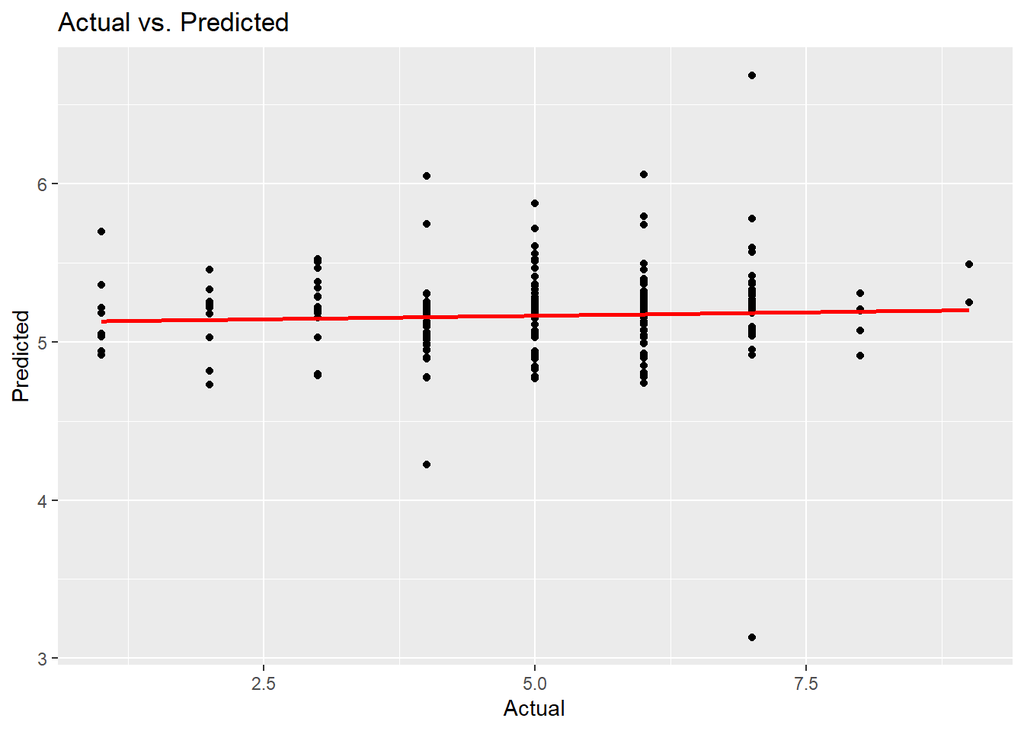

```r
results = data.frame(actual = test_2023$num_trending_days, predicted = pred.lasso_2023)
ggplot(results, aes(x = actual, y = s0)) +
  geom_point() +
  xlab("Actual") +
  ylab("Predicted") +
  ggtitle("Actual vs. Predicted") +
  geom_smooth(method = "lm", se = FALSE, color = "red")
```

then make plots for category variables:

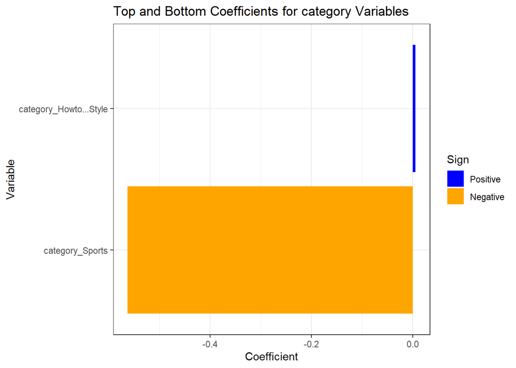

```
##                 variable   coeff
## 1 category_Howto...Style  0.0028
## 2        category_Sports -0.2814
## 3 category_Howto...Style  0.0028
## 4        category_Sports -0.2814
```

```r
plot_coefficients(coef_table, "category", 5, 5)
```

then make plots for tag variables:

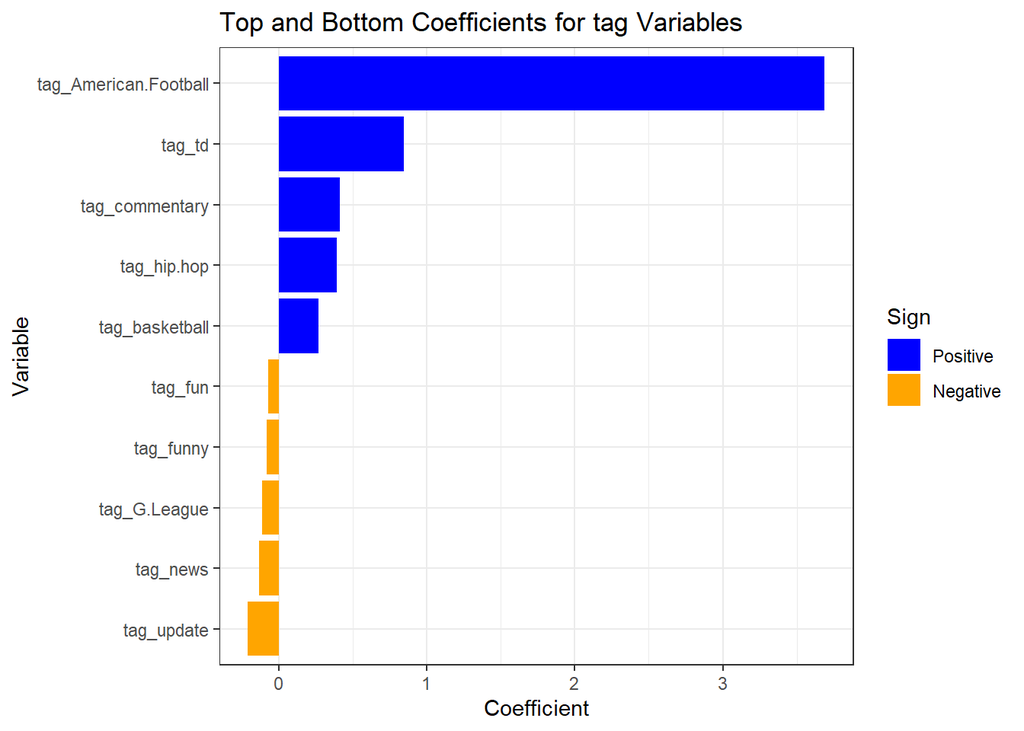

```
##                 variable   coeff
## 1  tag_American.Football  3.6860
## 2                 tag_td  0.8449
## 3         tag_commentary  0.4159
## 4            tag_hip.hop  0.3960
## 5         tag_basketball  0.2709
## 16               tag_fun -0.0688
## 17             tag_funny -0.0811
## 18          tag_G.League -0.1107
## 19              tag_news -0.1294
## 20            tag_update -0.2065
```

```r
plot_coefficients(coef_table, "tag", 5, 5)
```

then make plots for channel variables:

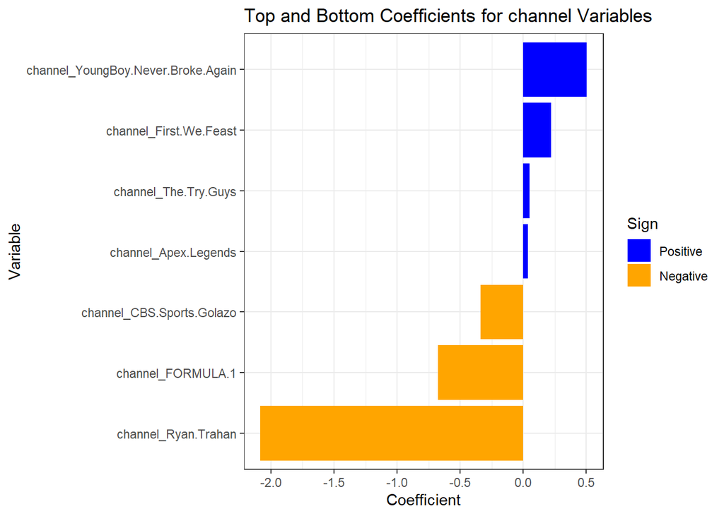

```
##                              variable   coeff
## 1  channel_YoungBoy.Never.Broke.Again  0.5043
## 2              channel_First.We.Feast  0.2197
## 3                channel_The.Try.Guys  0.0251
## 4                channel_Apex.Legends  0.0187
## 5           channel_CBS.Sports.Golazo -0.1698
## 31               channel_The.Try.Guys  0.0251
## 41               channel_Apex.Legends  0.0187
## 51          channel_CBS.Sports.Golazo -0.1698
## 6                   channel_FORMULA.1 -0.6753
## 7                 channel_Ryan.Trahan -2.0855
```

```r
plot_coefficients(coef_table, "channel", 5, 5)
```

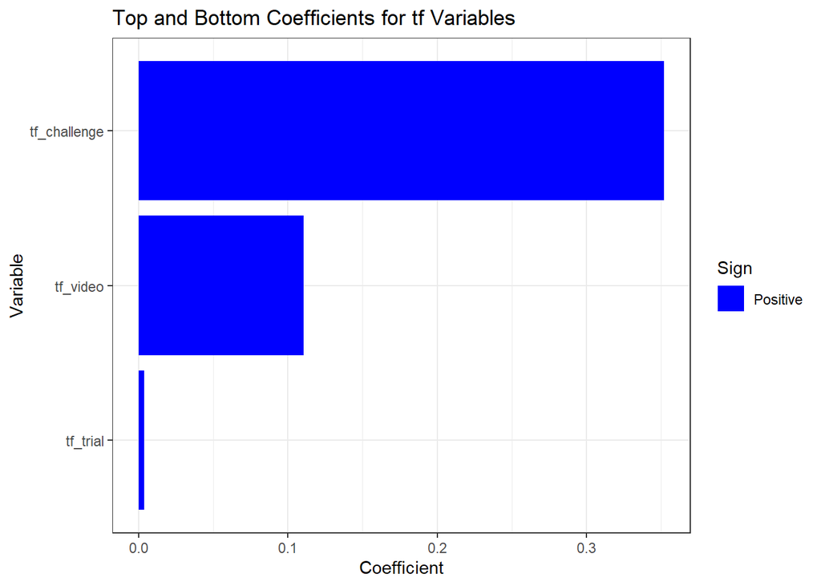

```
##       variable  coeff
## 1 tf_challenge 0.1759
## 2     tf_video 0.0553
## 3     tf_trial 0.0019
## 4 tf_challenge 0.1759
## 5     tf_video 0.0553
## 6     tf_trial 0.0019
```

```r
plot_coefficients(coef_table, "tf", 5, 5)
```